# R Notebook

```r
suppressPackageStartupMessages({
  library(ArchR)
  library(knitr)
  library(TFBSTools)
  library(ComplexHeatmap)
  library(ggplot2)
  library(ggrepel)
  library(qdapTools)
  library(parallel)
})
```

[output not shown]

```r
addArchRThreads(threads = 62)
```

```
Setting default number of Parallel threads to 62.
```

```r
set.seed(1)
projNC <- loadArchRProject(path = "/data/Austin/10XscATAC/ArchR_data_final_thesis/")
```

[output not shown]

```r
projNC@projectMetadata$outputDirectory <- "./Figure_Exports"
projNC <- addImputeWeights(projNC, sampleCells = 10000, nRep = 3, k = 20)
```

```
ArchR logging to : ArchRLogs/ArchR-addImputeWeights-1c762ee29366-Date-2022-06-14_Time-20-27-39.log
If there is an issue, please report to github with logFile!
2022-06-14 20:27:39 : Computing Impute Weights Using Magic (Cell 2018), 0 mins elapsed.
```

```r
cluster_to_identity <- data.frame(cluster = paste0("C",1:10),
                                  identity = c("C1_Melanocytes","C2_Sensory_Glia","C3_Int_Mesenchyme",
                                               "C4_Multipotent_NC","C5_Hindbrain_Neurons","C6_Somatosensory_Neurons",
                                               "C7_Midbrain_Neurons","C8_Early_Mesenchyme","C9_Sensory_Neurons",
                                               "C10_Late_Mesenchyme"))
projNC$Cell_Identity <- lookup(projNC$Clusters, cluster_to_identity)
```

# Figure 1 - Dimensionality Reduction & Clustering

## B

A two-dimensional UMAP projection colored by original sample identity (timepoint).

```r
p1 <- plotEmbedding(projNC, embedding = "UMAP", colorBy = "cellColData",
                    name = "Sample", plotAs = "points",
                    pal = ArchRPalettes$bear, size = 0.2, rastr = F)
```

```
ArchR logging to : ArchRLogs/ArchR-plotEmbedding-fcb26a33439a-Date-2022-06-11_Time-23-38-34.log
If there is an issue, please report to github with logFile!
```

|  | IterativeLSI#UMAP_Dimension_1 | IterativeLSI#UMAP_Dimension_2 |
| --- | --- | --- |
| HH12#AGCCTGGTCCACGCTT-1 | 4.4112038 | 2.276715 |
| HH12#TACAGCACAACTACTG-1 | 2.5044708 | 2.088989 |
| HH12#GTCTACCAGGAAGAAC-1 | 4.5683660 | 2.264409 |
| HH12#CGGACTGGTAACGTAA-1 | 2.5286884 | 2.071348 |
| HH12#CTGGGACTCGGTTAGT-1 | 2.6069586 | 2.088019 |
| HH12#TGAGTCAAGGATCCTT-1 | 0.9036467 | 2.563635 |

```
Plotting Embedding
1
ArchR logging successful to : ArchRLogs/ArchR-plotEmbedding-fcb26a33439a-Date-2022-06-11_Time-23-38-34.log
```

```r
plotPDF(p1, name = "Plot-UMAP-Sample.pdf", ArchRProj = projNC, addDOC = FALSE, width = 8, height = 8)
```

```
Plotting Ggplot!
```

[figure not shown]

```r
p1
```

## C

A two-dimensional UMAP projection followed by clustering in ArchR.

```r
p2 <- plotEmbedding(projNC, embedding = "UMAP", colorBy = "cellColData",
                    name = "Clusters", plotAs = "points", size = 0.2, rastr = F)
```

```
ArchR logging to : ArchRLogs/ArchR-plotEmbedding-fcb2592bb200-Date-2022-06-11_Time-23-38-38.log
If there is an issue, please report to github with logFile!
```

|  | IterativeLSI#UMAP_Dimension_1 | IterativeLSI#UMAP_Dimension_2 |
| --- | --- | --- |
| HH12#AGCCTGGTCCACGCTT-1 | 4.4112038 | 2.276715 |
| HH12#TACAGCACAACTACTG-1 | 2.5044708 | 2.088989 |
| HH12#GTCTACCAGGAAGAAC-1 | 4.5683660 | 2.264409 |
| HH12#CGGACTGGTAACGTAA-1 | 2.5286884 | 2.071348 |
| HH12#CTGGGACTCGGTTAGT-1 | 2.6069586 | 2.088019 |
| HH12#TGAGTCAAGGATCCTT-1 | 0.9036467 | 2.563635 |

```
Plotting Embedding
1
ArchR logging successful to : ArchRLogs/ArchR-plotEmbedding-fcb2592bb200-Date-2022-06-11_Time-23-38-38.log
```

```r
plotPDF(p2, name = "Plot-UMAP-Clusters.pdf", ArchRProj = projNC, addDOC = FALSE, width = 8, height = 8)
```

```
Plotting Ggplot!
```

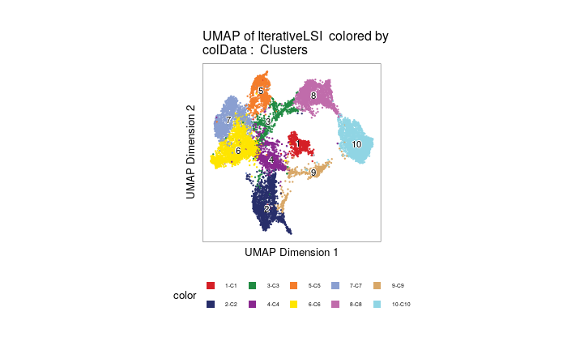

```r
p2
```

```r
p3 <- plotEmbedding(projNC, embedding = "UMAP", colorBy = "cellColData",
                    name = "Cell_Identity", plotAs = "points", size = 0.2, rastr = F)
```

```
ArchR logging to : ArchRLogs/ArchR-plotEmbedding-fcb25425e8ff-Date-2022-06-11_Time-23-38-43.log
If there is an issue, please report to github with logFile!
```

|  | IterativeLSI#UMAP_Dimension_1 | IterativeLSI#UMAP_Dimension_2 |
| --- | --- | --- |
| HH12#AGCCTGGTCCACGCTT-1 | 4.4112038 | 2.276715 |
| HH12#TACAGCACAACTACTG-1 | 2.5044708 | 2.088989 |
| HH12#GTCTACCAGGAAGAAC-1 | 4.5683660 | 2.264409 |
| HH12#CGGACTGGTAACGTAA-1 | 2.5286884 | 2.071348 |
| HH12#CTGGGACTCGGTTAGT-1 | 2.6069586 | 2.088019 |
| HH12#TGAGTCAAGGATCCTT-1 | 0.9036467 | 2.563635 |

```
Plotting Embedding
1
ArchR logging successful to : ArchRLogs/ArchR-plotEmbedding-fcb25425e8ff-Date-2022-06-11_Time-23-38-43.log
```

```r
plotPDF(p3, name = "Plot-UMAP-Cell_Identity.pdf", ArchRProj = projNC, addDOC = FALSE, width = 8, height = 8)
```

```
Plotting Ggplot!
```

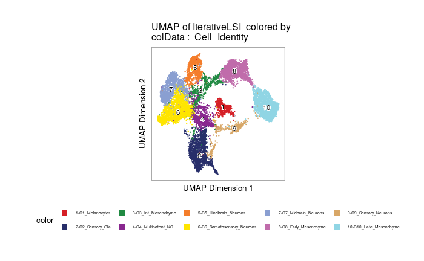

```r
p3
```

## D

A customized plot of enriched chromVAR motifs in the UMAP projection.

```r
motifs <- c("Pou5f1..Sox2","RUNX1","ASCL1","MEIS2","MITF","TWIST1","GRHL2","OTX2")

grey_red <- ArchRPalettes$whiteRed
grey_red[1] <- "grey"

plotting_motifs <- getFeatures(projNC, select = paste(motifs, collapse="|"), useMatrix = "MotifMatrix")

plotting_motifs_z <- paste0("z:",plotting_motifs)

# Problem with threads > 1...
motif_plot_nocutoff <- plotEmbedding(projNC,
                                     embedding = "UMAP",
                                     colorBy = "MotifMatrix",
                                     name = plotting_motifs_z,
                                     plotAs = "points",
                                     sampleCells = NULL,
                                     rastr = F,
                                     keepAxis = F,
                                     threads = 1)
```

```
Getting ImputeWeights
ArchR logging to : ArchRLogs/ArchR-plotEmbedding-fcb225b576a0-Date-2022-06-11_Time-23-38-48.log
If there is an issue, please report to github with logFile!
```

|  | IterativeLSI#UMAP_Dimension_1 | IterativeLSI#UMAP_Dimension_2 |
| --- | --- | --- |
| HH12#AGCCTGGTCCACGCTT-1 | 4.4112038 | 2.276715 |
| HH12#TACAGCACAACTACTG-1 | 2.5044708 | 2.088989 |
| HH12#GTCTACCAGGAAGAAC-1 | 4.5683660 | 2.264409 |
| HH12#CGGACTGGTAACGTAA-1 | 2.5286884 | 2.071348 |
| HH12#CTGGGACTCGGTTAGT-1 | 2.6069586 | 2.088019 |
| HH12#TGAGTCAAGGATCCTT-1 | 0.9036467 | 2.563635 |

```
2022-06-11 23:38:49 : Getting Matrix Values...
1 2 3 4 5 6 7
Imputing Matrix
Plotting Embedding
1 2 3 4 5 6 7 8 9 10
ArchR logging successful to : ArchRLogs/ArchR-plotEmbedding-fcb225b576a0-Date-2022-06-11_Time-23-38-48.log
```

```r
for (plot in seq(length(motif_plot_nocutoff))){
  plotPDF(motif_plot_nocutoff[[plot]], name = paste0("Plot-Motif-Zscores-",plot),
          addDOC = FALSE, ArchRProj = projNC, width = 5, height = 5)
}
```

```
Plotting Ggplot!
Plotting Ggplot!
Plotting Ggplot!
Plotting Ggplot!
Plotting Ggplot!
Plotting Ggplot!
Plotting Ggplot!
Plotting Ggplot!
Plotting Ggplot!
Plotting Ggplot!
```

```r
combined <- cowplot::plot_grid(motif_plot_nocutoff[[1]],motif_plot_nocutoff[[2]],
                               motif_plot_nocutoff[[4]],motif_plot_nocutoff[[3]],
                               motif_plot_nocutoff[[8]],motif_plot_nocutoff[[7]],
                               motif_plot_nocutoff[[10]],motif_plot_nocutoff[[9]], nrow = 2)


plotPDF(combined, name = "Plot-Motif-Zscores.pdf", ArchRProj = projNC, addDOC = FALSE, width = 16, height = 16)
```

```
Plotting Ggplot!
```

[figure not shown]

```r
combined
```

## E

A UMAP projection of the ‘end’ of each lineage

```r
end1 <- plotEmbedding(projNC, embedding = "UMAP", colorBy = "cellColData",
                      highlightCells = projNC$cellNames[projNC$Cell_Identity == "C2_Sensory_Glia"],
                    name = "Cell_Identity", plotAs = "points", size = 0.2, rastr = F)
```

```
ArchR logging to : ArchRLogs/ArchR-plotEmbedding-fcb2395b695-Date-2022-06-11_Time-23-41-54.log
If there is an issue, please report to github with logFile!
```

|  | IterativeLSI#UMAP_Dimension_1 | IterativeLSI#UMAP_Dimension_2 |
| --- | --- | --- |
| HH12#AGCCTGGTCCACGCTT-1 | 4.4112038 | 2.276715 |
| HH12#TACAGCACAACTACTG-1 | 2.5044708 | 2.088989 |
| HH12#GTCTACCAGGAAGAAC-1 | 4.5683660 | 2.264409 |
| HH12#CGGACTGGTAACGTAA-1 | 2.5286884 | 2.071348 |
| HH12#CTGGGACTCGGTTAGT-1 | 2.6069586 | 2.088019 |
| HH12#TGAGTCAAGGATCCTT-1 | 0.9036467 | 2.563635 |

```
Plotting Embedding
1
ArchR logging successful to : ArchRLogs/ArchR-plotEmbedding-fcb2395b695-Date-2022-06-11_Time-23-41-54.log
```

```r
plotPDF(end1, name = "Plot-UMAP-SensoryGlia.pdf", ArchRProj = projNC, addDOC = FALSE, width = 8, height = 8)
```

```
Plotting Ggplot!
```

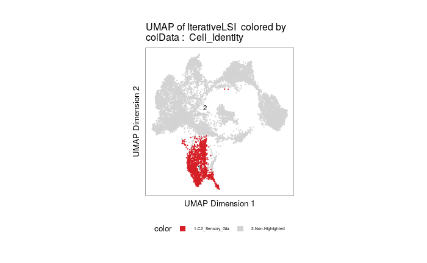

```r
end1
```

```r
end2 <- plotEmbedding(projNC, embedding = "UMAP", colorBy = "cellColData",
                      highlightCells = projNC$cellNames[projNC$Cell_Identity == "C9_Sensory_Neurons"],
                    name = "Cell_Identity", plotAs = "points", size = 0.2, rastr = F)
```

```
ArchR logging to : ArchRLogs/ArchR-plotEmbedding-fcb27860545a-Date-2022-06-11_Time-23-41-58.log
If there is an issue, please report to github with logFile!
```

|  | IterativeLSI#UMAP_Dimension_1 | IterativeLSI#UMAP_Dimension_2 |
| --- | --- | --- |
| HH12#AGCCTGGTCCACGCTT-1 | 4.4112038 | 2.276715 |
| HH12#TACAGCACAACTACTG-1 | 2.5044708 | 2.088989 |
| HH12#GTCTACCAGGAAGAAC-1 | 4.5683660 | 2.264409 |
| HH12#CGGACTGGTAACGTAA-1 | 2.5286884 | 2.071348 |
| HH12#CTGGGACTCGGTTAGT-1 | 2.6069586 | 2.088019 |
| HH12#TGAGTCAAGGATCCTT-1 | 0.9036467 | 2.563635 |

```
Plotting Embedding
1
ArchR logging successful to : ArchRLogs/ArchR-plotEmbedding-fcb27860545a-Date-2022-06-11_Time-23-41-58.log
```

```r
plotPDF(end2, name = "Plot-UMAP-SensoryNeurons.pdf", ArchRProj = projNC, addDOC = FALSE, width = 8, height = 8)
```

```
Plotting Ggplot!
```

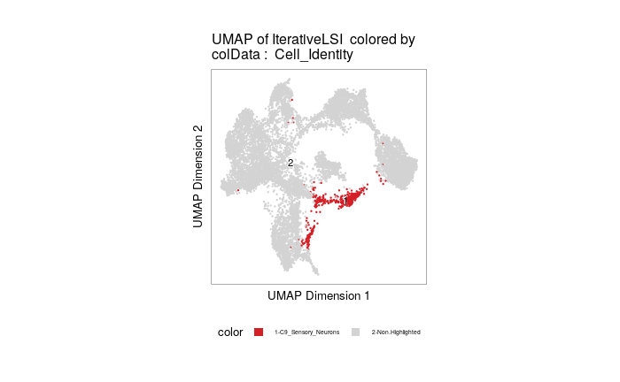

```r
end2
```

```r
end3 <- plotEmbedding(projNC, embedding = "UMAP", colorBy = "cellColData",
                      highlightCells = projNC$cellNames[projNC$Cell_Identity == "C7_Midbrain_Neurons"],
                    name = "Cell_Identity", plotAs = "points", size = 0.2, rastr = F)
```

```
ArchR logging to : ArchRLogs/ArchR-plotEmbedding-fcb2486651f0-Date-2022-06-11_Time-23-42-02.log
If there is an issue, please report to github with logFile!
```

|  | IterativeLSI#UMAP_Dimension_1 | IterativeLSI#UMAP_Dimension_2 |
| --- | --- | --- |
| HH12#AGCCTGGTCCACGCTT-1 | 4.4112038 | 2.276715 |
| HH12#TACAGCACAACTACTG-1 | 2.5044708 | 2.088989 |
| HH12#GTCTACCAGGAAGAAC-1 | 4.5683660 | 2.264409 |
| HH12#CGGACTGGTAACGTAA-1 | 2.5286884 | 2.071348 |
| HH12#CTGGGACTCGGTTAGT-1 | 2.6069586 | 2.088019 |
| HH12#TGAGTCAAGGATCCTT-1 | 0.9036467 | 2.563635 |

```
Plotting Embedding
1
ArchR logging successful to : ArchRLogs/ArchR-plotEmbedding-fcb2486651f0-Date-2022-06-11_Time-23-42-02.log
```

```r
plotPDF(end3, name = "Plot-UMAP-Midbrain_Neurons.pdf", ArchRProj = projNC, addDOC = FALSE, width = 8, height = 8)
```

```
Plotting Ggplot!
```

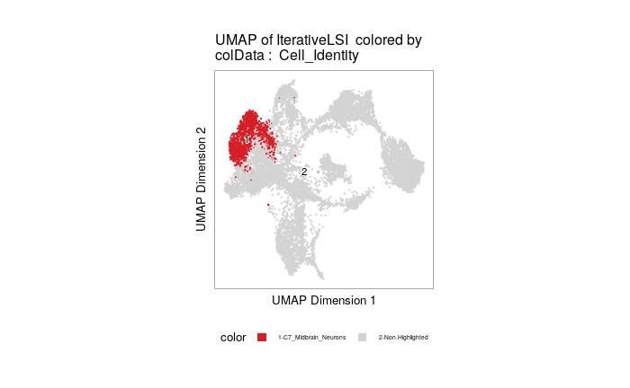

```r
end3
```

```r
end4 <- plotEmbedding(projNC, embedding = "UMAP", colorBy = "cellColData",
                      highlightCells = projNC$cellNames[projNC$Cell_Identity == "C5_Hindbrain_Neurons"],
                    name = "Cell_Identity", plotAs = "points", size = 0.2, rastr = F)
```

```
ArchR logging to : ArchRLogs/ArchR-plotEmbedding-fcb246a6a2b9-Date-2022-06-11_Time-23-42-07.log
If there is an issue, please report to github with logFile!
```

|  | IterativeLSI#UMAP_Dimension_1 | IterativeLSI#UMAP_Dimension_2 |
| --- | --- | --- |
| HH12#AGCCTGGTCCACGCTT-1 | 4.4112038 | 2.276715 |
| HH12#TACAGCACAACTACTG-1 | 2.5044708 | 2.088989 |
| HH12#GTCTACCAGGAAGAAC-1 | 4.5683660 | 2.264409 |
| HH12#CGGACTGGTAACGTAA-1 | 2.5286884 | 2.071348 |
| HH12#CTGGGACTCGGTTAGT-1 | 2.6069586 | 2.088019 |
| HH12#TGAGTCAAGGATCCTT-1 | 0.9036467 | 2.563635 |

```
Plotting Embedding
1
ArchR logging successful to : ArchRLogs/ArchR-plotEmbedding-fcb246a6a2b9-Date-2022-06-11_Time-23-42-07.log
```

```r
plotPDF(end4, name = "Plot-UMAP-Hindbrain_Neurons.pdf", ArchRProj = projNC, addDOC = FALSE, width = 8, height = 8)
```

```
Plotting Ggplot!
```

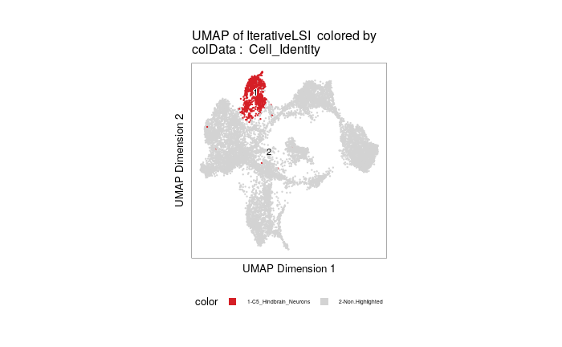

```r
end4
```

```r
end5 <- plotEmbedding(projNC, embedding = "UMAP", colorBy = "cellColData",
                      highlightCells = projNC$cellNames[projNC$Cell_Identity == "C10_Late_Mesenchyme"],
                    name = "Cell_Identity", plotAs = "points", size = 0.2, rastr = F)
```

```
ArchR logging to : ArchRLogs/ArchR-plotEmbedding-fcb27cddab12-Date-2022-06-11_Time-23-42-11.log
If there is an issue, please report to github with logFile!
```

|  | IterativeLSI#UMAP_Dimension_1 | IterativeLSI#UMAP_Dimension_2 |
| --- | --- | --- |
| HH12#AGCCTGGTCCACGCTT-1 | 4.4112038 | 2.276715 |
| HH12#TACAGCACAACTACTG-1 | 2.5044708 | 2.088989 |
| HH12#GTCTACCAGGAAGAAC-1 | 4.5683660 | 2.264409 |
| HH12#CGGACTGGTAACGTAA-1 | 2.5286884 | 2.071348 |
| HH12#CTGGGACTCGGTTAGT-1 | 2.6069586 | 2.088019 |
| HH12#TGAGTCAAGGATCCTT-1 | 0.9036467 | 2.563635 |

```
Plotting Embedding
1
ArchR logging successful to : ArchRLogs/ArchR-plotEmbedding-fcb27cddab12-Date-2022-06-11_Time-23-42-11.log
```

```r
plotPDF(end5, name = "Plot-UMAP-Late_Mesenchyme.pdf", ArchRProj = projNC, addDOC = FALSE, width = 8, height = 8)
```

```
Plotting Ggplot!
```

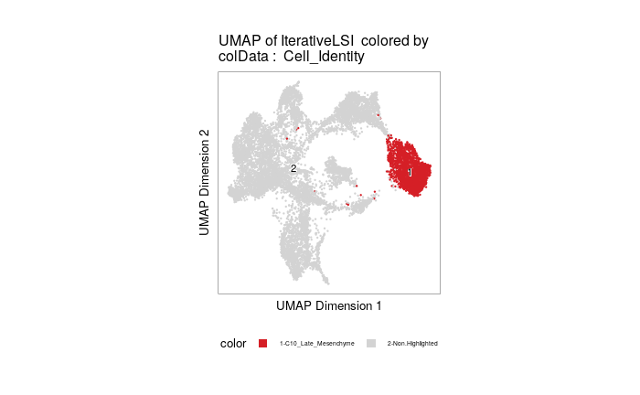

```r
end5
```

```r
end6 <- plotEmbedding(projNC, embedding = "UMAP", colorBy = "cellColData",
                      highlightCells = projNC$cellNames[projNC$Cell_Identity == "C6_Somatosensory_Neurons"],
                    name = "Cell_Identity", plotAs = "points", size = 0.2, rastr = F)
```

```
ArchR logging to : ArchRLogs/ArchR-plotEmbedding-fcb232a8fe11-Date-2022-06-11_Time-23-42-15.log
If there is an issue, please report to github with logFile!
```

|  | IterativeLSI#UMAP_Dimension_1 | IterativeLSI#UMAP_Dimension_2 |
| --- | --- | --- |
| HH12#AGCCTGGTCCACGCTT-1 | 4.4112038 | 2.276715 |
| HH12#TACAGCACAACTACTG-1 | 2.5044708 | 2.088989 |
| HH12#GTCTACCAGGAAGAAC-1 | 4.5683660 | 2.264409 |
| HH12#CGGACTGGTAACGTAA-1 | 2.5286884 | 2.071348 |
| HH12#CTGGGACTCGGTTAGT-1 | 2.6069586 | 2.088019 |
| HH12#TGAGTCAAGGATCCTT-1 | 0.9036467 | 2.563635 |

```
Plotting Embedding
1
ArchR logging successful to : ArchRLogs/ArchR-plotEmbedding-fcb232a8fe11-Date-2022-06-11_Time-23-42-15.log
```

```r
plotPDF(end6, name = "Plot-UMAP-Somatosensory_Neurons.pdf", ArchRProj = projNC, addDOC = FALSE, width = 8, height = 8)
```

```
Plotting Ggplot!
```

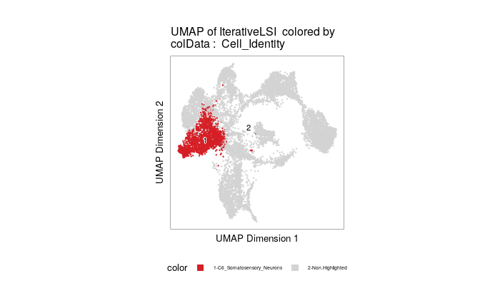

```r
end6
```

# Figure S1 - QC Metrics

We saved a pre-filtering version of our object, and use it here to show pre-filtering QC.

## Prep

```r
projNC_pre <- loadArchRProject(path = "/data/Austin/10XscATAC/ArchR_Prefiltered/")
```

[output not shown]

## A

```r
p4 <- plotFragmentSizes(ArchRProj = projNC_pre)
```

```
ArchR logging to : ArchRLogs/ArchR-plotFragmentSizes-fcb2346654a4-Date-2022-06-11_Time-23-44-10.log
If there is an issue, please report to github with logFile!
```

## B

```r
p5 <- plotGroups(
    ArchRProj = projNC_pre,
    groupBy = "Sample",
    colorBy = "cellColData",
    name = "TSSEnrichment",
    plotAs = "violin",
    alpha = 0.4,
    addBoxPlot = TRUE,
    discreteSet = "bear"
   ) + geom_hline(linetype = 5, size = 1,show.legend = F, yintercept = 3.5)
```

```
1
```

```r
plotPDF(p5, name = "Prefiltered-Plot-Sample-TSS.pdf", ArchRProj = projNC_pre, addDOC = FALSE, width = 8, height = 8)
```

```
Plotting Ggplot!
```

```r
p5
```

```r
p6 <- plotGroups(
    ArchRProj = projNC_pre,
    groupBy = "Sample",
    colorBy = "cellColData",
    name = "FRIP",
    plotAs = "violin",
    alpha = 0.4,
    addBoxPlot = TRUE,
    discreteSet = "bear"
   ) + geom_hline(linetype = 5, size = 1,show.legend = F, yintercept = 0.4)
```

```
1
```

```r
plotPDF(p6, name = "Prefiltered-Plot-Sample-FRiP.pdf", ArchRProj = projNC_pre, addDOC = FALSE, width = 8, height = 8)
```

```
Plotting Ggplot!
```

```r
p6
```

## C

```r
p7 <- plotEmbedding(ArchRProj = projNC_pre, colorBy = "cellColData", name = "DoubletCall", embedding = "UMAP", size = 1, baseSize = 14, plotAs = "points")
```

```
ArchR logging to : ArchRLogs/ArchR-plotEmbedding-42a792f57f9-Date-2021-05-09_Time-11-29-35.log
If there is an issue, please report to github with logFile!
Getting UMAP Embedding
```

|  | IterativeLSI#UMAP_Dimension_1 | IterativeLSI#UMAP_Dimension_2 |
| --- | --- | --- |
| HH12#AGCCTGGTCCACGCTT-1 | 5.4611343 | 2.509977 |
| HH12#TACAGCACAACTACTG-1 | 2.7166043 | 3.019301 |
| HH12#GTCTACCAGGAAGAAC-1 | 5.5790766 | 2.415363 |
| HH12#CGGACTGGTAACGTAA-1 | 2.4543351 | 2.515810 |
| HH12#CTCAACCGTGTTTCTT-1 | -0.8068874 | 2.703229 |
| HH12#CTGGGACTCGGTTAGT-1 | 2.4412282 | 2.639032 |

```
ColorBy = cellColData
Plotting Embedding
1
ArchR logging successful to : ArchRLogs/ArchR-plotEmbedding-42a792f57f9-Date-2021-05-09_Time-11-29-35.log
```

```r
plotPDF(p7, name = "Prefiltered-Plot-UMAP-Doublet.pdf", ArchRProj = projNC_pre, addDOC = FALSE, width = 8, height = 8)
```

```
Plotting Ggplot!
```

```r
p7
```

## D

```r
p8 <- plotGroups(
    ArchRProj = projNC_pre,
    groupBy = "Sample",
    colorBy = "cellColData",
    name = "log10(nFrags)",
    plotAs = "violin",
    alpha = 0.4,
    addBoxPlot = TRUE,
    discreteSet = "bear"
   ) + geom_hline(linetype = 5, size = 1,show.legend = F, yintercept = 3.3)
```

```
1
```

```r
plotPDF(p8, name = "Prefiltered-Plot-Sample-Depth.pdf", ArchRProj = projNC_pre, addDOC = FALSE, width = 8, height = 8)
```

```
Plotting Ggplot!
```

```r
p8
```

## E

Extra motif plots of markers

```r
motifs <- c("YY2","SIX3","TFAP2A","PAX6","FOXD3","NR2F2","RFX3", "ZIC1")

grey_red <- ArchRPalettes$whiteRed
grey_red[1] <- "grey"

plotting_motifs <- getFeatures(projNC, select = paste(motifs, collapse="|"), useMatrix = "MotifMatrix")

plotting_motifs_z <- paste0("z:",plotting_motifs)

# Problem with threads > 1...
motif_plot_supp <- plotEmbedding(projNC,
                                     embedding = "UMAP",
                                     colorBy = "MotifMatrix",
                                     name = plotting_motifs_z,
                                     plotAs = "points",
                                     sampleCells = NULL,
                                     rastr = F,
                                     keepAxis = F,
                                     threads = 1,
                                    randomize = F)
```

```
Getting ImputeWeights
ArchR logging to : ArchRLogs/ArchR-plotEmbedding-fcb25a0670fc-Date-2022-06-11_Time-23-46-19.log
If there is an issue, please report to github with logFile!
```

|  | IterativeLSI#UMAP_Dimension_1 | IterativeLSI#UMAP_Dimension_2 |
| --- | --- | --- |
| HH12#AGCCTGGTCCACGCTT-1 | 4.4112038 | 2.276715 |
| HH12#TACAGCACAACTACTG-1 | 2.5044708 | 2.088989 |
| HH12#GTCTACCAGGAAGAAC-1 | 4.5683660 | 2.264409 |
| HH12#CGGACTGGTAACGTAA-1 | 2.5286884 | 2.071348 |
| HH12#CTGGGACTCGGTTAGT-1 | 2.6069586 | 2.088019 |
| HH12#TGAGTCAAGGATCCTT-1 | 0.9036467 | 2.563635 |

```
2022-06-11 23:46:20 : Getting Matrix Values...
1 2 3 4 5 6 7
Imputing Matrix
Plotting Embedding
1 2 3 4 5 6 7 8 9 10 11
ArchR logging successful to : ArchRLogs/ArchR-plotEmbedding-fcb25a0670fc-Date-2022-06-11_Time-23-46-19.log
```

```r
for (plot in seq(length(motif_plot_supp))){
  plotPDF(motif_plot_supp[[plot]], name = paste0("Plot-Motif-Zscores-Supp-",plot),
          addDOC = FALSE, ArchRProj = projNC, width = 5, height = 5)
}
```

```
Plotting Ggplot!
Plotting Ggplot!
Plotting Ggplot!
Plotting Ggplot!
Plotting Ggplot!
Plotting Ggplot!
Plotting Ggplot!
Plotting Ggplot!
Plotting Ggplot!
Plotting Ggplot!
Plotting Ggplot!
```

```r
# Digging into neuronal clusters.

# Class B dILA Neurons
# LHX1/5 PAX2 DRGX LBX2 GBX1 EN1
neuron_motifs <- c("LBX2","TLX2","LHX5","GBX1")

grey_red <- ArchRPalettes$whiteRed
grey_red[1] <- "grey"

plotting_neuron_motifs <- getFeatures(projNC, select = paste(neuron_motifs, collapse="|"), useMatrix = "MotifMatrix")

plotting_neuron_motifs_z <- paste0("z:",plotting_neuron_motifs)

# Problem with threads > 1...
motif_plot_neurons <- plotEmbedding(projNC,
                                     embedding = "UMAP",
                                     colorBy = "MotifMatrix",
                                     name = plotting_neuron_motifs_z,
                                     plotAs = "points",
                                     sampleCells = NULL,
                                     rastr = F,
                                     keepAxis = F,
                                     threads = 1,
                                     randomize = F)
```

```
Getting ImputeWeights
ArchR logging to : ArchRLogs/ArchR-plotEmbedding-fcb259a6354c-Date-2022-06-11_Time-23-46-59.log
If there is an issue, please report to github with logFile!
```

|  | IterativeLSI#UMAP_Dimension_1 | IterativeLSI#UMAP_Dimension_2 |
| --- | --- | --- |
| HH12#AGCCTGGTCCACGCTT-1 | 4.4112038 | 2.276715 |
| HH12#TACAGCACAACTACTG-1 | 2.5044708 | 2.088989 |
| HH12#GTCTACCAGGAAGAAC-1 | 4.5683660 | 2.264409 |
| HH12#CGGACTGGTAACGTAA-1 | 2.5286884 | 2.071348 |
| HH12#CTGGGACTCGGTTAGT-1 | 2.6069586 | 2.088019 |
| HH12#TGAGTCAAGGATCCTT-1 | 0.9036467 | 2.563635 |

```
2022-06-11 23:47:00 : Getting Matrix Values...
1 2 3 4 5 6 7
Imputing Matrix
Plotting Embedding
1 2 3 4
ArchR logging successful to : ArchRLogs/ArchR-plotEmbedding-fcb259a6354c-Date-2022-06-11_Time-23-46-59.log
```

```
$`z:LBX2_193`

$`z:GBX1_372`

$`z:LHX5_500`

$`z:TLX2_555`
```

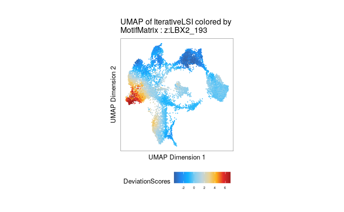

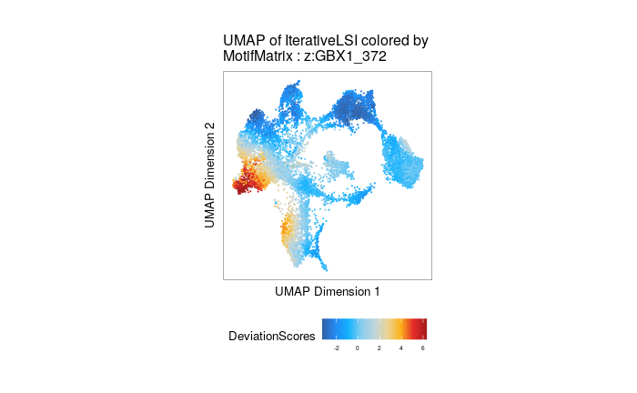

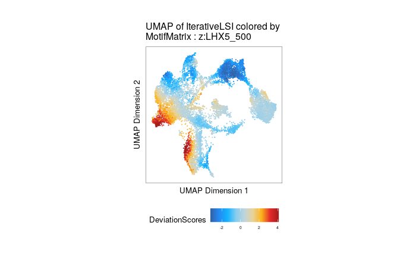

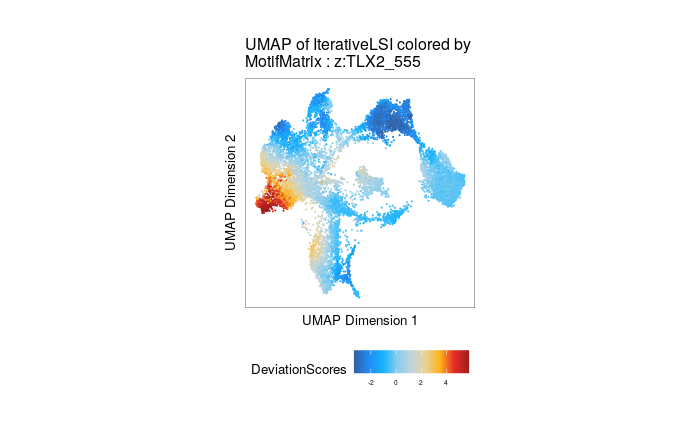

```r
motif_plot_neurons
```

```r
for (plot in seq(length(motif_plot_neurons))){
  plotPDF(motif_plot_neurons[[plot]], name = paste0("Plot-Motif-Zscores-C6-",plot),
          addDOC = FALSE, ArchRProj = projNC, width = 5, height = 5)
}
```

```
Plotting Ggplot!
Plotting Ggplot!
Plotting Ggplot!
Plotting Ggplot!
```

```r
# tbd neural 1
# dopaminergic neurons of substantia nigra?
# OTX2 RFX4 DMBX1 PITX3 RHOXF1

neuron_motifs_2 <- c("DMBX1","RHOXF1","PITX3","Arid3a")

grey_red <- ArchRPalettes$whiteRed
grey_red[1] <- "grey"

plotting_neuron_motifs_2 <- getFeatures(projNC, select = paste(neuron_motifs_2, collapse="|"), useMatrix = "MotifMatrix")

plotting_neuron_motifs_2_z <- paste0("z:",plotting_neuron_motifs_2)

motif_plot_neurons_2 <- plotEmbedding(projNC,
                                     embedding = "UMAP",
                                     colorBy = "MotifMatrix",
                                     name = plotting_neuron_motifs_2_z,
                                     plotAs = "points",
                                     sampleCells = NULL,
                                     rastr = F,
                                     keepAxis = F,
                                     threads = 1,
                                     randomize = F)
```

```
Getting ImputeWeights
ArchR logging to : ArchRLogs/ArchR-plotEmbedding-fcb23a933224-Date-2022-06-11_Time-23-47-25.log
If there is an issue, please report to github with logFile!
```

|  | IterativeLSI#UMAP_Dimension_1 | IterativeLSI#UMAP_Dimension_2 |
| --- | --- | --- |
| HH12#AGCCTGGTCCACGCTT-1 | 4.4112038 | 2.276715 |
| HH12#TACAGCACAACTACTG-1 | 2.5044708 | 2.088989 |
| HH12#GTCTACCAGGAAGAAC-1 | 4.5683660 | 2.264409 |
| HH12#CGGACTGGTAACGTAA-1 | 2.5286884 | 2.071348 |
| HH12#CTGGGACTCGGTTAGT-1 | 2.6069586 | 2.088019 |
| HH12#TGAGTCAAGGATCCTT-1 | 0.9036467 | 2.563635 |

```
2022-06-11 23:47:27 : Getting Matrix Values...
1 2 3 4 5 6 7
Imputing Matrix
Plotting Embedding
1 2 3 4
ArchR logging successful to : ArchRLogs/ArchR-plotEmbedding-fcb23a933224-Date-2022-06-11_Time-23-47-25.log
```

```
$`z:Arid3a_43`

$`z:PITX3_205`

$`z:RHOXF1_210`

$`z:Dmbx1_366`
```

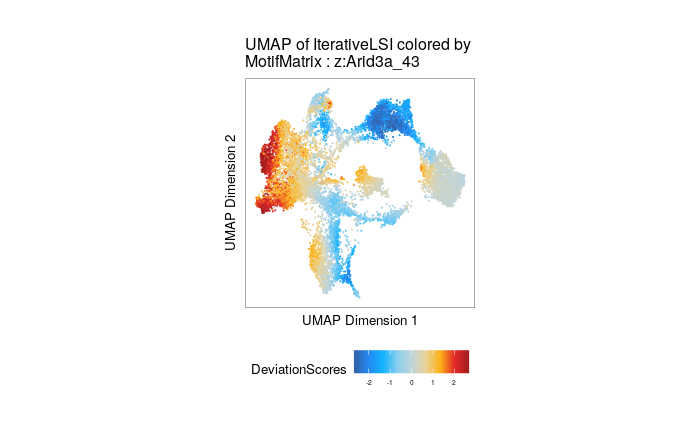

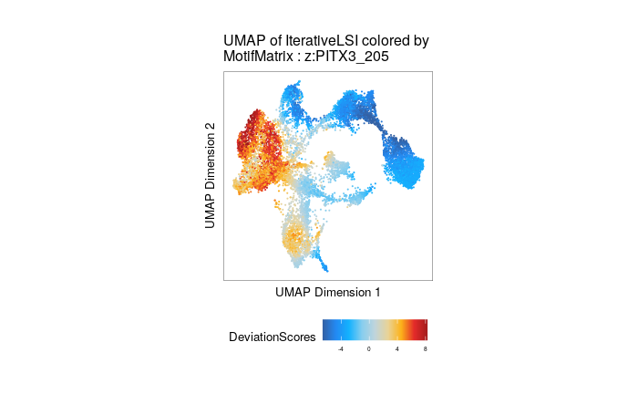

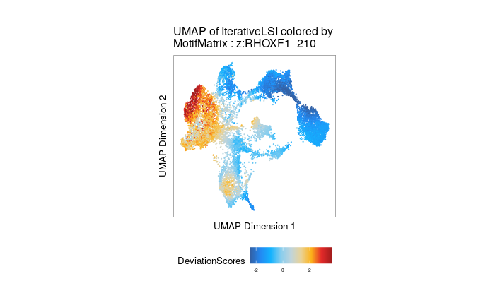

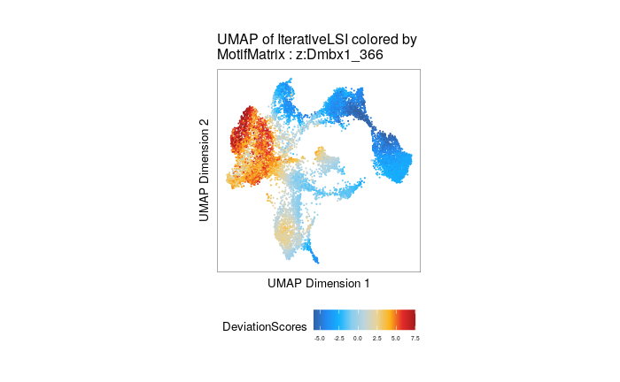

```r
motif_plot_neurons_2
```

```r
for (plot in seq(length(motif_plot_neurons_2))){
  plotPDF(motif_plot_neurons_2[[plot]], name = paste0("Plot-Motif-Zscores-C7-",plot),
          addDOC = FALSE, ArchRProj = projNC, width = 5, height = 5)
}
```

```
Plotting Ggplot!
Plotting Ggplot!
Plotting Ggplot!
Plotting Ggplot!
```

```r
# neural 2
# RFX4 PBX1 MEIS2 SOX10
# Check KROX20 genescore for these guys?

neuron_motifs_3 <- c("RFX4","PBX1","PAX3","SOX10")

grey_red <- ArchRPalettes$whiteRed
grey_red[1] <- "grey"

plotting_neuron_motifs_3 <- getFeatures(projNC, select = paste(neuron_motifs_3, collapse="|"), useMatrix = "MotifMatrix")

plotting_neuron_motifs_3_z <- paste0("z:",plotting_neuron_motifs_3)

motif_plot_neurons_3 <- plotEmbedding(projNC,
                                     embedding = "UMAP",
                                     colorBy = "MotifMatrix",
                                     name = plotting_neuron_motifs_3_z,
                                     plotAs = "points",
                                     sampleCells = NULL,
                                     rastr = F,
                                     keepAxis = F,
                                     threads = 1,
                                     randomize = F)
```

```
Getting ImputeWeights
ArchR logging to : ArchRLogs/ArchR-plotEmbedding-fcb27b782d53-Date-2022-06-11_Time-23-47-51.log
If there is an issue, please report to github with logFile!
```

|  | IterativeLSI#UMAP_Dimension_1 | IterativeLSI#UMAP_Dimension_2 |
| --- | --- | --- |
| HH12#AGCCTGGTCCACGCTT-1 | 4.4112038 | 2.276715 |
| HH12#TACAGCACAACTACTG-1 | 2.5044708 | 2.088989 |
| HH12#GTCTACCAGGAAGAAC-1 | 4.5683660 | 2.264409 |
| HH12#CGGACTGGTAACGTAA-1 | 2.5286884 | 2.071348 |
| HH12#CTGGGACTCGGTTAGT-1 | 2.6069586 | 2.088019 |
| HH12#TGAGTCAAGGATCCTT-1 | 0.9036467 | 2.563635 |

```
2022-06-11 23:47:53 : Getting Matrix Values...
1 2 3 4 5 6 7
Imputing Matrix
Plotting Embedding
1 2 3 4 5
ArchR logging successful to : ArchRLogs/ArchR-plotEmbedding-fcb27b782d53-Date-2022-06-11_Time-23-47-51.log
```

```
$`z:PBX1_15`

$`z:PAX3_269`

$`z:RFX4_287`

$`z:SOX10_407`

$`z:PAX3.var.2_525`
```

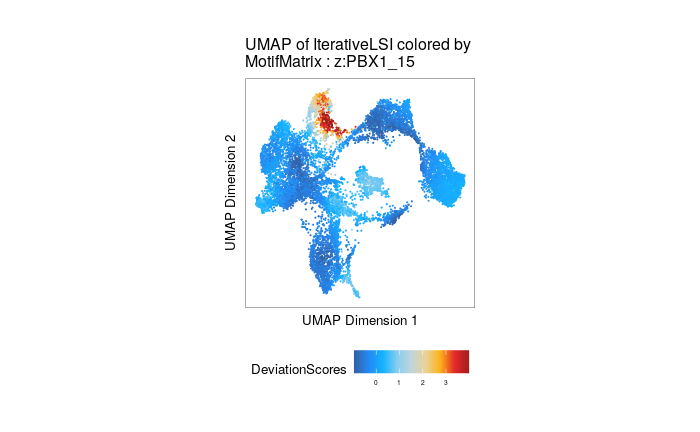

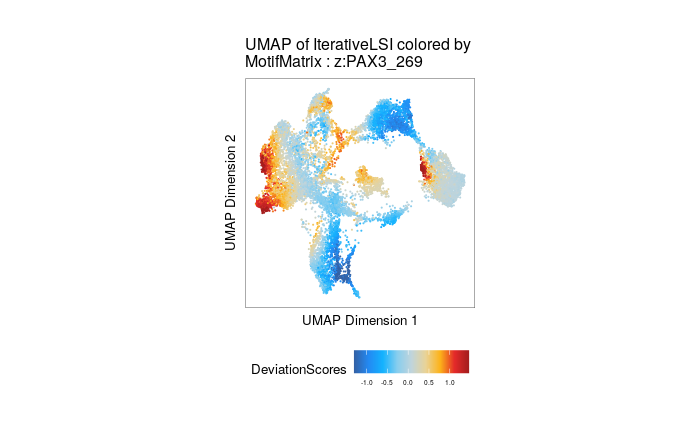

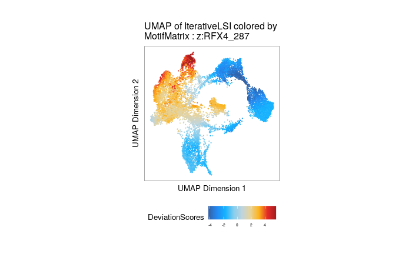

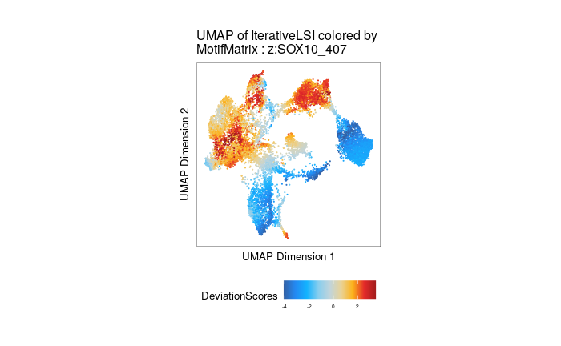

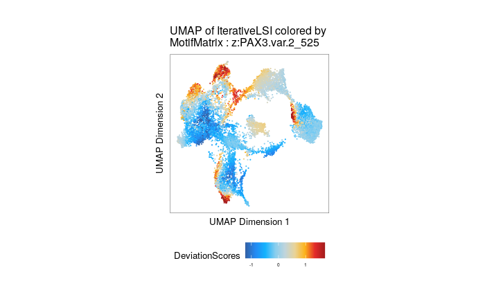

```r
motif_plot_neurons_3
```

```r
for (plot in seq(length(motif_plot_neurons_3))){
  plotPDF(motif_plot_neurons_3[[plot]], name = paste0("Plot-Motif-Zscores-C5-",plot),
          addDOC = FALSE, ArchRProj = projNC, width = 5, height = 5)
}
```

```
Plotting Ggplot!
Plotting Ggplot!
Plotting Ggplot!
Plotting Ggplot!
Plotting Ggplot!
```

## F

A heatmap of the top changing motifs

```r
#scales::show_col(unlist(ArchRPalettes))
Cluster_Motifs <- getMarkerFeatures(
    ArchRProj = projNC,
    useMatrix = "MotifMatrix",
    groupBy = "Clusters",
    bias = c("log10(nFrags)"),
    maxCells = 750,
    testMethod = "wilcoxon",
    useSeqnames = "z", threads = 1)
```

```
ArchR logging to : ArchRLogs/ArchR-getMarkerFeatures-fcb25c6a66f4-Date-2022-06-11_Time-23-48-19.log
If there is an issue, please report to github with logFile!
2022-06-11 23:48:19 : Matching Known Biases, 0.001 mins elapsed.
```

|  | log10(nFrags) | name |
| --- | --- | --- |
| median | 3.7622283 | foreground |
| mean | 3.7899842 | foreground |
| sd | 0.3111819 | foreground |
| lowerQuartile | 3.5363059 | foreground |
| upperQuartile | 4.0030726 | foreground |

|  | log10(nFrags) | name |
| --- | --- | --- |
| median | 3.7623784 | background |
| mean | 3.7903028 | background |
| sd | 0.3108074 | background |
| lowerQuartile | 3.5303278 | background |
| upperQuartile | 3.9992176 | background |

|  | log10(nFrags) | name |
| --- | --- | --- |
| median | 4.4519399 | foreground |
| mean | 4.3522735 | foreground |
| sd | 0.4038426 | foreground |
| lowerQuartile | 4.1275259 | foreground |
| upperQuartile | 4.6604196 | foreground |

|  | log10(nFrags) | name |
| --- | --- | --- |
| median | 4.4528593 | background |
| mean | 4.3522989 | background |
| sd | 0.4041363 | background |
| lowerQuartile | 4.1269751 | background |
| upperQuartile | 4.6615193 | background |

|  | log10(nFrags) | name |
| --- | --- | --- |
| median | 4.5501731 | foreground |
| mean | 4.3181920 | foreground |
| sd | 0.5367413 | foreground |
| lowerQuartile | 3.8448491 | foreground |
| upperQuartile | 4.7512094 | foreground |

|  | log10(nFrags) | name |
| --- | --- | --- |
| median | 4.5485121 | background |
| mean | 4.3183389 | background |
| sd | 0.5364563 | background |
| lowerQuartile | 3.8511611 | background |
| upperQuartile | 4.7516472 | background |

|  | log10(nFrags) | name |
| --- | --- | --- |
| median | 4.2864452 | foreground |
| mean | 4.2264802 | foreground |
| sd | 0.3742735 | foreground |
| lowerQuartile | 3.9665172 | foreground |
| upperQuartile | 4.5123604 | foreground |

|  | log10(nFrags) | name |
| --- | --- | --- |
| median | 4.2845094 | background |
| mean | 4.2265058 | background |
| sd | 0.3741652 | background |
| lowerQuartile | 3.9673487 | background |
| upperQuartile | 4.5110641 | background |

|  | log10(nFrags) | name |
| --- | --- | --- |
| median | 4.473983 | foreground |
| mean | 4.371440 | foreground |
| sd | 0.397549 | foreground |
| lowerQuartile | 4.122511 | foreground |
| upperQuartile | 4.680997 | foreground |

|  | log10(nFrags) | name |
| --- | --- | --- |
| median | 4.4736037 | background |
| mean | 4.3714371 | background |
| sd | 0.3976814 | background |
| lowerQuartile | 4.1272344 | background |
| upperQuartile | 4.6817386 | background |

|  | log10(nFrags) | name |
| --- | --- | --- |
| median | 4.5641925 | foreground |
| mean | 4.4644141 | foreground |
| sd | 0.3635575 | foreground |
| lowerQuartile | 4.3139726 | foreground |
| upperQuartile | 4.7194307 | foreground |

|  | log10(nFrags) | name |
| --- | --- | --- |
| median | 4.5634455 | background |
| mean | 4.4641258 | background |
| sd | 0.3637837 | background |
| lowerQuartile | 4.3140358 | background |
| upperQuartile | 4.7172959 | background |

|  | log10(nFrags) | name |
| --- | --- | --- |
| median | 4.3794504 | foreground |
| mean | 4.3055901 | foreground |
| sd | 0.4092514 | foreground |
| lowerQuartile | 4.0256540 | foreground |
| upperQuartile | 4.6263579 | foreground |

|  | log10(nFrags) | name |
| --- | --- | --- |
| median | 4.379876 | background |
| mean | 4.305390 | background |
| sd | 0.409437 | background |
| lowerQuartile | 4.025736 | background |
| upperQuartile | 4.626058 | background |

|  | log10(nFrags) | name |
| --- | --- | --- |
| median | 4.6601537 | foreground |
| mean | 4.5174840 | foreground |
| sd | 0.3906532 | foreground |
| lowerQuartile | 4.3544734 | foreground |
| upperQuartile | 4.7900739 | foreground |

|  | log10(nFrags) | name |
| --- | --- | --- |
| median | 4.6592124 | background |
| mean | 4.5173055 | background |
| sd | 0.3904627 | background |
| lowerQuartile | 4.3557005 | background |
| upperQuartile | 4.7889669 | background |

|  | log10(nFrags) | name |
| --- | --- | --- |
| median | 4.4939030 | foreground |
| mean | 4.3958327 | foreground |
| sd | 0.3770383 | foreground |
| lowerQuartile | 4.2096691 | foreground |
| upperQuartile | 4.6826390 | foreground |

|  | log10(nFrags) | name |
| --- | --- | --- |
| median | 4.4930395 | background |
| mean | 4.3960632 | background |
| sd | 0.3769227 | background |
| lowerQuartile | 4.2088980 | background |
| upperQuartile | 4.6818419 | background |

|  | log10(nFrags) | name |
| --- | --- | --- |
| median | 4.2581342 | foreground |
| mean | 4.2159559 | foreground |
| sd | 0.4039032 | foreground |
| lowerQuartile | 3.9469433 | foreground |
| upperQuartile | 4.5225877 | foreground |

|  | log10(nFrags) | name |
| --- | --- | --- |
| median | 4.2594505 | background |
| mean | 4.2162701 | background |
| sd | 0.4037029 | background |
| lowerQuartile | 3.9464031 | background |
| upperQuartile | 4.5239155 | background |

```
2022-06-11 23:48:23 : Computing Pairwise Tests (1 of 10), 0.064 mins elapsed.
```

|  | log2Mean | log2FC | fdr | pval | mean1 | mean2 | n | auc |
| --- | --- | --- | --- | --- | --- | --- | --- | --- |
| f1 | 8.277978 | 9.5044877 | 1.909586e-57 | 2.943732e-58 | 1.4427589 | -0.0003414334 | 429 | 0.8173505 |
| f2 | NaN | 4.4757162 | 2.574734e-08 | 1.321881e-08 | -0.3426551 | -0.0176266525 | 429 | 0.3879136 |
| f3 | NaN | NaN | 8.117701e-06 | 4.951145e-06 | -0.2597986 | 0.0323939817 | 429 | 0.4099304 |
| f4 | 7.259625 | 2.7760598 | 9.213891e-10 | 4.261116e-10 | 0.6210547 | 0.0886769892 | 429 | 0.6231492 |
| f5 | 7.180214 | 0.8280362 | 2.091791e-02 | 1.634738e-02 | 0.4301743 | 0.2412972911 | 429 | 0.5473563 |
| f6 | 7.831762 | 1.3962024 | 8.069139e-07 | 4.467231e-07 | 0.7673513 | 0.2900927889 | 429 | 0.5995566 |

```
2022-06-11 23:48:25 : Computing Pairwise Tests (2 of 10), 0.093 mins elapsed.
```

|  | log2Mean | log2FC | fdr | pval | mean1 | mean2 | n | auc |
| --- | --- | --- | --- | --- | --- | --- | --- | --- |
| f1 | NaN | NaN | 1.258239e-03 | 8.618768e-04 | -0.1986136 | 0.073479888 | 745 | 0.4501437 |
| f2 | NaN | NaN | 2.059763e-16 | 7.675794e-17 | -0.5218769 | 0.036916635 | 745 | 0.3752732 |
| f3 | 5.658340 | NaN | 1.501010e-02 | 1.132800e-02 | 0.1385165 | -0.005618511 | 745 | 0.5378911 |
| f4 | 8.117011 | NaN | 2.685857e-41 | 5.040483e-42 | 0.8476884 | -0.105061705 | 745 | 0.7032332 |
| f5 | 7.966173 | 2.918777 | 4.175383e-11 | 1.886199e-11 | 0.5915729 | 0.077064426 | 745 | 0.6004648 |
| f6 | 8.594668 | 3.329438 | 1.361085e-21 | 4.232866e-22 | 0.9425857 | 0.092560461 | 745 | 0.6446142 |

```
2022-06-11 23:48:27 : Computing Pairwise Tests (3 of 10), 0.123 mins elapsed.
```

|  | log2Mean | log2FC | fdr | pval | mean1 | mean2 | n | auc |
| --- | --- | --- | --- | --- | --- | --- | --- | --- |
| f1 | NaN | NaN | 1.697993e-18 | 7.738840e-20 | -0.78438516 | 0.060815556 | 436 | 0.3216480 |
| f2 | NaN | NaN | 1.836392e-04 | 8.517316e-05 | -0.30556196 | 0.026174194 | 436 | 0.4231283 |
| f3 | 4.182143 | 1.513777 | 6.899876e-01 | 6.372674e-01 | 0.05937987 | 0.019304043 | 436 | 0.5092269 |
| f4 | NaN | NaN | 6.036266e-01 | 5.413220e-01 | -0.06348945 | 0.007090683 | 436 | 0.4880481 |
| f5 | NaN | NaN | 9.037625e-12 | 1.272052e-12 | -1.01165012 | 0.198896165 | 436 | 0.3611544 |
| f6 | NaN | NaN | 1.133305e-09 | 2.233188e-10 | -0.82274452 | 0.080768994 | 436 | 0.3758838 |

```
2022-06-11 23:48:29 : Computing Pairwise Tests (4 of 10), 0.155 mins elapsed.
```

|  | log2Mean | log2FC | fdr | pval | mean1 | mean2 | n | auc |
| --- | --- | --- | --- | --- | --- | --- | --- | --- |
| f1 | NaN | NaN | 1.944600e-33 | 2.059295e-34 | -0.7465745 | 0.10618933 | 690 | 0.3098005 |
| f2 | NaN | NaN | 1.380392e-77 | 4.811019e-79 | -1.1039782 | 0.09963497 | 690 | 0.2073367 |
| f3 | NaN | NaN | 1.467472e-05 | 7.573417e-06 | -0.1689778 | 0.06604504 | 690 | 0.4303949 |
| f4 | 6.835911 | 4.882432 | 2.343084e-04 | 1.359994e-04 | 0.3188200 | 0.00940890 | 690 | 0.5593195 |
| f5 | 3.914993 | NaN | 6.534076e-01 | 6.069859e-01 | -0.1192961 | 0.16012066 | 690 | 0.4920017 |
| f6 | 6.999990 | 1.328967 | 1.913837e-02 | 1.367393e-02 | 0.2639283 | 0.10418509 | 690 | 0.5383365 |

```
2022-06-11 23:48:30 : Computing Pairwise Tests (5 of 10), 0.184 mins elapsed.
```

|  | log2Mean | log2FC | fdr | pval | mean1 | mean2 | n | auc |
| --- | --- | --- | --- | --- | --- | --- | --- | --- |
| f1 | NaN | NaN | 8.515176e-06 | 4.942455e-06 | -0.23244575 | 0.10029927 | 725 | 0.4307272 |
| f2 | 7.661383 | NaN | 3.938021e-28 | 8.815676e-29 | 0.63167658 | -0.07596760 | 725 | 0.6688342 |
| f3 | 4.151361 | NaN | 6.163163e-03 | 4.444748e-03 | 0.09669012 | -0.05042843 | 725 | 0.5431477 |
| f4 | NaN | NaN | 1.151471e-03 | 7.594152e-04 | -0.17777898 | 0.05661460 | 725 | 0.4489284 |
| f5 | NaN | NaN | 5.642629e-09 | 2.745676e-09 | -0.68535898 | 0.18824018 | 725 | 0.4098131 |
| f6 | NaN | NaN | 5.484898e-10 | 2.448353e-10 | -0.51474470 | 0.13968165 | 725 | 0.4039876 |

```
2022-06-11 23:48:32 : Computing Pairwise Tests (6 of 10), 0.214 mins elapsed.
```

|  | log2Mean | log2FC | fdr | pval | mean1 | mean2 | n | auc |
| --- | --- | --- | --- | --- | --- | --- | --- | --- |
| f1 | NaN | NaN | 4.350693e-15 | 2.361971e-15 | -0.42111499 | 0.15736086 | 745 | 0.3814891 |
| f2 | 4.259085 | NaN | 9.758130e-03 | 8.515473e-03 | 0.10860980 | -0.05989166 | 745 | 0.5393649 |
| f3 | NaN | NaN | 3.262962e-08 | 2.208842e-08 | -0.27377711 | 0.07296193 | 745 | 0.4162894 |
| f4 | 5.999814 | NaN | 4.046289e-05 | 3.042853e-05 | 0.19581688 | -0.02671150 | 745 | 0.5623963 |
| f5 | NaN | NaN | 6.358020e-22 | 3.025599e-22 | -0.81862254 | 0.49127403 | 745 | 0.3548723 |
| f6 | 6.197280 | NaN | 7.417469e-04 | 6.035393e-04 | -0.05609564 | 0.25039953 | 745 | 0.4486789 |

```
2022-06-11 23:48:34 : Computing Pairwise Tests (7 of 10), 0.243 mins elapsed.
```

|  | log2Mean | log2FC | fdr | pval | mean1 | mean2 | n | auc |
| --- | --- | --- | --- | --- | --- | --- | --- | --- |
| f1 | 5.634675 | -0.6038223 | 6.417344e-01 | 5.918408e-01 | 0.05152132 | 0.078995584 | 746 | 0.4919823 |
| f2 | 7.980139 | NaN | 1.646109e-46 | 1.721133e-47 | 0.76584959 | -0.091587213 | 746 | 0.7164448 |
| f3 | 7.352685 | NaN | 4.358839e-14 | 1.361407e-14 | 0.44436316 | -0.008846765 | 746 | 0.6151306 |
| f4 | 6.330234 | NaN | 2.807570e-05 | 1.512926e-05 | 0.21843870 | -0.005404091 | 746 | 0.5646954 |
| f5 | NaN | NaN | 5.239183e-62 | 3.300826e-63 | -1.61317463 | 0.397938358 | 746 | 0.2490728 |
| f6 | NaN | NaN | 1.457517e-50 | 1.367644e-51 | -1.26368005 | 0.320588977 | 746 | 0.2740568 |

```
2022-06-11 23:48:36 : Computing Pairwise Tests (8 of 10), 0.273 mins elapsed.
```

|  | log2Mean | log2FC | fdr | pval | mean1 | mean2 | n | auc |
| --- | --- | --- | --- | --- | --- | --- | --- | --- |
| f1 | 5.611233 | -3.033346 | 4.013044e-01 | 3.749453e-01 | 0.01294161 | 0.115600860 | 745 | 0.4867240 |
| f2 | NaN | NaN | 1.196983e-06 | 7.814082e-07 | -0.24182315 | 0.081197205 | 745 | 0.4260871 |
| f3 | NaN | NaN | 6.834892e-07 | 4.434434e-07 | -0.28191984 | 0.009275293 | 745 | 0.4244512 |
| f4 | NaN | NaN | 2.044203e-13 | 1.033062e-13 | -0.45863819 | 0.080190360 | 745 | 0.3887320 |
| f5 | NaN | NaN | 1.070393e-20 | 4.864117e-21 | -1.14561184 | 0.330266067 | 745 | 0.3591748 |
| f6 | NaN | NaN | 4.266866e-35 | 1.521430e-35 | -1.15806459 | 0.273718557 | 745 | 0.3138219 |

```
2022-06-11 23:48:38 : Computing Pairwise Tests (9 of 10), 0.307 mins elapsed.
```

|  | log2Mean | log2FC | fdr | pval | mean1 | mean2 | n | auc |
| --- | --- | --- | --- | --- | --- | --- | --- | --- |
| f1 | 7.666541 | NaN | 3.228685e-31 | 2.943037e-32 | 1.2115508 | -0.082111683 | 358 | 0.7552979 |
| f2 | 5.444910 | 7.381321 | 3.608927e-02 | 2.907460e-02 | 0.2391041 | -0.001342414 | 358 | 0.5471271 |
| f3 | 4.869306 | NaN | 1.233546e-02 | 9.375615e-03 | 0.1871058 | -0.029404436 | 358 | 0.5561000 |
| f4 | 6.760218 | 3.680332 | 6.223384e-06 | 3.537151e-06 | 0.5589726 | 0.041025971 | 358 | 0.6001217 |
| f5 | 9.716568 | NaN | 8.027328e-67 | 8.608394e-69 | 4.7756109 | -0.080899541 | 358 | 0.8784838 |
| f6 | 9.231071 | 6.618912 | 3.624376e-55 | 1.797613e-56 | 3.3205853 | 0.031020105 | 358 | 0.8418979 |

```
2022-06-11 23:48:40 : Computing Pairwise Tests (10 of 10), 0.338 mins elapsed.
```

|  | log2Mean | log2FC | fdr | pval | mean1 | mean2 | n | auc |
| --- | --- | --- | --- | --- | --- | --- | --- | --- |
| f1 | 7.844830 | NaN | 1.094955e-37 | 4.388628e-38 | 0.7348417 | -0.12035906 | 745 | 0.6930409 |
| f2 | 6.280002 | NaN | 2.312043e-05 | 1.651902e-05 | 0.2292938 | -0.02336480 | 745 | 0.5644484 |
| f3 | 6.806642 | 2.520422 | 2.131129e-04 | 1.576921e-04 | 0.2545759 | 0.04326219 | 745 | 0.5565371 |
| f4 | NaN | NaN | 1.181080e-57 | 3.910548e-58 | -0.8218243 | 0.25021799 | 745 | 0.2595054 |
| f5 | 9.932720 | NaN | 7.997331e-124 | 1.039867e-124 | 2.7202971 | -0.09924502 | 745 | 0.8553849 |
| f6 | 9.140767 | 3.141197 | 6.323086e-51 | 2.169853e-51 | 1.3597535 | 0.15293219 | 745 | 0.7256394 |

```
###########
2022-06-11 23:48:41 : Completed Pairwise Tests, 0.368 mins elapsed.
###########
ArchR logging successful to : ArchRLogs/ArchR-getMarkerFeatures-fcb25c6a66f4-Date-2022-06-11_Time-23-48-19.log
```

```r
Motif_list <- getMarkers(Cluster_Motifs, cutOff = "FDR <= 1e-50")
Motif_df <- as.data.frame(Motif_list)
top_Motifs <- Motif_df %>% dplyr::group_by(group_name) %>% dplyr::top_n(30, wt = -log10(FDR))

# Motifs by cluster mean Z-Score?
temp <- Cluster_Motifs@assays@data$Mean
# Add rownames
rownames(temp) <- Cluster_Motifs@elementMetadata$name

temp_f <- temp[unique(top_Motifs$name),]

temp_f_t <- t(temp_f)

# Who do we want to label?

label_motifs <- c("TWIST1_741", "OTX2_718","SNAI2_729",
                  "Dmbx1_366","ZEB1_412","ZBTB18_192","Pou5f1..Sox2_38",
                  "RUNX1_41","ASCL1_594","MEIS2_262","MITF_707","GRHL2_693",
                  "YY2_744","SIX1_405","TFAP2A_739","PAX6_14","NR2F2_399",
                  "RFX3_725","SP4_177","FOXD2_604","Atoh1_306","NEUROG2_162",
                  "SCRT1_727","Rarg_344","PITX2_526","SOX9_20","PHOX2B_720","ETV4_682",
                  "KLF2_496","ELK1_357","ZIC1_190","PAX3.var.2_525","PBX1_15",
                  "SOX10_407","TLX2_555","LHX5_500","LBX2_193","GBX1_372",
                  "PITX3_205","Arid3a_43","RHOXF1_210","MITF_707")

label_index <- which(colnames(temp_f_t) %in% label_motifs)
label_text <- toupper(stringr::str_split(colnames(temp_f_t)[label_index], pattern = "_", simplify = T)[,1])

heatmap1 <- ComplexHeatmap::Heatmap(matrix = temp_f_t,
                                    cluster_rows = T,
                                    cluster_columns = T,
                                    show_row_names = T,
                                    show_column_names = F,
                                    use_raster = F,
                                    col = as.character(ArchRPalettes$blueYellow),
                                    bottom_annotation = HeatmapAnnotation(
                                      names = anno_mark(at = label_index,
                                                        labels = label_text, which = "row", labels_rot = 90)))


plotPDF(heatmap1, name = "Plot-Motif-Heatmap.pdf", ArchRProj = projNC, addDOC = FALSE, width = 10, height = 8)
```

```
Plotting ComplexHeatmap!
```

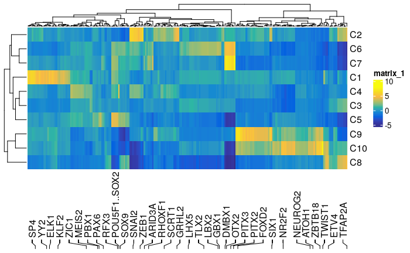

```r
heatmap1
```

# Figure 2 - Pseudotime

## A

```r
# How many cells for each lineage?
summary(as.factor(projNC$Cell_Identity))
```

```
          C1_Melanocytes      C10_Late_Mesenchyme          C2_Sensory_Glia
                     543                     2241                     1756
       C3_Int_Mesenchyme        C4_Multipotent_NC     C5_Hindbrain_Neurons
                     552                      868                      912
C6_Somatosensory_Neurons      C7_Midbrain_Neurons      C8_Early_Mesenchyme
                    2189                     1444                     1699
      C9_Sensory_Neurons
                     452
```

## B

Motifs that change over pseudotime. Highlighting the mesencyhme, midbrain, somatosensory, and hindbrain neurons, sensory ganglia, and sensory neuron lineages. First we have to isolate the cells of that lineage to perform the analysis on (differentially enriched). Then, we aggregate transcription factor signal by family to reduce noise. Finally, we plot a heatmap and label specific transcription factors of interest in each lineage.

```r
matrix_agg_scores <- function(input = sm_mat, transpose = T) {
  ## A function to aggregate motif scores by family.

  if (transpose){
    input <- t(input)
  }
  # Convert to DF
  input <- as.data.frame(input)
  # Clean up names
  colnames(input) <- toupper(colnames(input))

  # GRHL
  if (any(c("GRHL1","GRHL2","GRHL3") %in% colnames(input))){
    print("Collapsing GRHL's")
    # Which are present?
    select <- c("GRHL1","GRHL2","GRHL3")[c("GRHL1","GRHL2","GRHL3") %in% colnames(input)]
    GRHL_Family <- Matrix::rowMeans(input[,select])
    input <- input[!colnames(input) %in% select]
    input$GRHL_Family <- GRHL_Family
  }
  # TEAD
  if (any(c("TEAD1","TEAD2","TEAD3","TEAD4") %in% colnames(input))){
    print("Collapsing TEAD's")
    # Which are present?
    select <- c("TEAD1","TEAD2","TEAD3","TEAD4")[c("TEAD1","TEAD2","TEAD3","TEAD4") %in% colnames(input)]
    TEAD_Family <- Matrix::rowMeans(input[,select])
    input <- input[!colnames(input) %in% select]
    input$TEAD_Family <- TEAD_Family
  }

  # TFAP2
  if (any(grep(pattern = "TFAP2", colnames(input), value = T) %in% colnames(input))){
    print("Collapsing TAFP2's")
    select <- grep(pattern = "TFAP2", colnames(input), value = T)[grep(pattern = "TFAP2", colnames(input), value = T) %in% colnames(input)]
    TFAP2_Family <- Matrix::rowMeans(input[,select])
    input <- input[!colnames(input) %in% select]
    input$TFAP2_Family <- TFAP2_Family
  }

  # SANI
  if (any(c("SNAI1", "SNAI2","SNAI3") %in% colnames(input))){
    print("Collapsing SANI's")
    # Which are present?
    select <- c("SNAI1", "SNAI2","SNAI3")[c("SNAI1", "SNAI2","SNAI3") %in% colnames(input)]
    SANI_Family <- Matrix::rowMeans(input[,select])
    input <- input[!colnames(input) %in% select]
    input$SANI_Family <- SANI_Family
  }

  # SOXB
  if (any(c("SOX1", "SOX2","SOX3") %in% colnames(input))){
    print("Collapsing SOXB's")
    # Which are present?
    select <- c("SOX1", "SOX2","SOX3")[c("SOX1", "SOX2","SOX3") %in% colnames(input)]
    SOXB_Family <- Matrix::rowMeans(input[,select])
    input <- input[!colnames(input) %in% select]
    input$SOXB_Family <- SOXB_Family
  }

  # SOXD
  if (any(c("SOX5", "SOX6","SOX13") %in% colnames(input))){
    print("Collapsing SOXD's")
    # Which are present?
    select <- c("SOX5", "SOX6","SOX13")[c("SOX5", "SOX6","SOX13") %in% colnames(input)]
    SOXD_Family <- Matrix::rowMeans(input[,select])
    input <- input[!colnames(input) %in% select]
    input$SOXD_Family <- SOXD_Family
  }

  # SOXE
  if (any(c("SOX8", "SOX9","SOX10") %in% colnames(input))){
    print("Collapsing SOXE's")
    # Which are present?
    select <- c("SOX8", "SOX9","SOX10")[c("SOX8", "SOX9","SOX10") %in% colnames(input)]
    SOXE_Family <- Matrix::rowMeans(input[,select])
    input <- input[!colnames(input) %in% select]
    input$SOXE_Family <- SOXE_Family
  }

  # SOXF
  if (any(c("SOX7", "SOX17","SOX18") %in% colnames(input))){
    print("Collapsing SOXF's")
    # Which are present?
    select <- c("SOX7", "SOX17","SOX18")[c("SOX7", "SOX17","SOX18") %in% colnames(input)]
    SOXF_Family <- Matrix::rowMeans(input[,select])
    input <- input[!colnames(input) %in% select]
    input$SOXF_Family <- SOXF_Family
  }

  # NR2F
  if (any(grep(pattern = "NR2F", colnames(input), value = T) %in% colnames(input))){
    print("Collapsing NR2F's")
    select <- grep(pattern = "NR2F", colnames(input), value = T)[grep(pattern = "NR2F", colnames(input), value = T) %in% colnames(input)]
    NR2F_Family <- Matrix::rowMeans(input[,select])
    input <- input[!colnames(input) %in% select]
    input$NR2F_Family <- NR2F_Family
  }

  # SP
  if (any(c("SP1", "SP2","SP3","SP4","SP8","SP9") %in% colnames(input))){
    print("Collapsing SP's")
    # Which are present?
    select <- c("SP1", "SP2","SP3","SP4","SP8","SP9")[c("SP1", "SP2","SP3","SP4","SP8","SP9") %in% colnames(input)]
    SP_Family <- Matrix::rowMeans(input[,select])
    input <- input[!colnames(input) %in% select]
    input$SP_Family <- SP_Family
  }

  # FOX
  if (any(grep(pattern = "FOX", colnames(input), value = T) %in% colnames(input))){
    print("Collapsing FOX's")
    select <- grep(pattern = "FOX", colnames(input), value = T)[grep(pattern = "FOX", colnames(input), value = T) %in% colnames(input)]
    FOX_Family <- Matrix::rowMeans(input[,select])
    input <- input[!colnames(input) %in% select]
    input$FOX_Family <- FOX_Family
  }

  # KLF
  if (any(grep(pattern = "KLF", colnames(input), value = T) %in% colnames(input))){
    print("Collapsing KLF's")
    select <- grep(pattern = "KLF", colnames(input), value = T)[grep(pattern = "KLF", colnames(input), value = T) %in% colnames(input)]
    KLF_Family <- Matrix::rowMeans(input[,select])
    input <- input[!colnames(input) %in% select]
    input$KLF_Family <- KLF_Family
  }

  # RFX
  if (any(grep(pattern = "RFX", colnames(input), value = T) %in% colnames(input))){
    print("Collapsing RFX's")
    select <- grep(pattern = "RFX", colnames(input), value = T)[grep(pattern = "RFX", colnames(input), value = T) %in% colnames(input)]
    RFX_Family <- Matrix::rowMeans(input[,select])
    input <- input[!colnames(input) %in% select]
    input$RFX_Family <- RFX_Family
  }

  # RXR
  if (any(grep(pattern = "RFR", colnames(input), value = T) %in% colnames(input))){
    print("Collapsing RFR's")
    select <- grep(pattern = "RFR", colnames(input), value = T)[grep(pattern = "RFR", colnames(input), value = T) %in% colnames(input)]
    RFR_Family <- Matrix::rowMeans(input[,select])
    input <- input[!colnames(input) %in% select]
    input$RFR_Family <- RFR_Family
  }

  # SIX
  if (any(grep(pattern = "SIX", colnames(input), value = T) %in% colnames(input))){
    print("Collapsing SIX's")
    select <- grep(pattern = "SIX", colnames(input), value = T)[grep(pattern = "SIX", colnames(input), value = T) %in% colnames(input)]
    SIX_Family <- Matrix::rowMeans(input[,select])
    input <- input[!colnames(input) %in% select]
    input$SIX_Family <- SIX_Family
  }

  # ETV
  if (any(grep(pattern = "ETV", colnames(input), value = T) %in% colnames(input))){
    print("Collapsing ETV's")
    select <- grep(pattern = "ETV", colnames(input), value = T)[grep(pattern = "ETV", colnames(input), value = T) %in% colnames(input)]
    ETV_Family <- Matrix::rowMeans(input[,select])
    input <- input[!colnames(input) %in% select]
    input$ETV_Family <- ETV_Family
  }

  return(input)
}
```

```r
# Motif scores per cell
motif_mat <- getMatrixFromProject(projNC,
                                  useMatrix = "MotifMatrix",
                                  useSeqnames = "z")
```

```
ArchR logging to : ArchRLogs/ArchR-getMatrixFromProject-afa97be20efb-Date-2022-06-13_Time-22-48-18.log
If there is an issue, please report to github with logFile!
2022-06-13 22:48:24 : Organizing colData, 0.11 mins elapsed.
2022-06-13 22:48:25 : Organizing rowData, 0.112 mins elapsed.
2022-06-13 22:48:25 : Organizing rowRanges, 0.112 mins elapsed.
2022-06-13 22:48:25 : Organizing Assays (1 of 1), 0.112 mins elapsed.
2022-06-13 22:48:26 : Constructing SummarizedExperiment, 0.141 mins elapsed.
2022-06-13 22:48:28 : Finished Matrix Creation, 0.169 mins elapsed.
```

```r
motif_mat_raw <- assay(motif_mat)
motif_mat_impute <- imputeMatrix(mat = motif_mat_raw,
                                 imputeWeights = getImputeWeights(projNC))
```

```
Getting ImputeWeights
ArchR logging to : ArchRLogs/ArchR-imputeMatrix-afa92d464d1d-Date-2022-06-13_Time-22-48-29.log
If there is an issue, please report to github with logFile!
```

```r
heatmap4 <- ComplexHeatmap::Heatmap(
  matrix = ordered_neural1[selected_motifs,],
  cluster_rows = T, cluster_columns = F, show_column_names = F,
  show_row_names = F, use_raster = F, row_title = "chromVAR z-score",
  column_title = "Cells ordered in Pseudotime: Hindbrain Neurons",
  col = as.character(ArchRPalettes$blueYellow)) +
  rowAnnotation(names = anno_mark(at = label_index, labels = label_text))

unique(neural1_motif_df$name)[row_order(heatmap4)]
```

```
 [1] "Pou5f1..Sox2_38" "ZNF24_413"       "MYOD1_709"       "SNAI3_537"       "RFX1_724"        "PKNOX1_721"
 [7] "PBX1_15"         "PAX6_14"         "SOX18_541"       "Sox17_21"        "MEIS3_263"       "POU4F3_279"
[13] "SOX15_444"       "RFX3_725"        "MEIS1.var.2_647" "MEIS2_262"       "EOMES_290"       "RFX5_288"
[19] "RFX2_283"        "RFX4_287"        "PBX3_401"        "PBX2_719"        "MEIS1_261"       "PAX9_270"
[25] "SOX9_20"         "SNAI2_729"       "SOX8_631"        "PAX1_268"        "POU4F2_175"      "SOX14_540"
[31] "RFX7_532"        "POU4F1_278"      "POU3F1_274"      "POU3F2_275"      "POU5F1B_280"     "POU3F4_277"
[37] "POU2F1_273"      "POU2F2_70"       "POU2F3_722"      "POU5F1_402"      "POU1F1_272"      "POU3F3_276"
[43] "Zic2_592"        "Zic1..Zic2_591"  "ZIC1_190"        "ZIC4_240"        "ZIC3_191"        "ZIC5_561"
[49] "LIN54_108"       "SOX13_408"       "TCF12.var.2_656" "TCF3_734"        "TCF4_735"        "ASCL1.var.2_639"
[55] "ZBTB32_558"      "TBX18_543"       "SCRT1_727"       "TBX6_545"        "TBX1_295"        "TBX2_182"
[61] "TBX21_184"       "TBX3_544"        "TBX20_183"       "TBR1_292"        "CTCF_37"         "SNAI1_536"
[67] "TBX4_296"        "TBX5_297"        "MGA_291"         "TBX15_293"       "ZEB1_412"        "Rbpjl_585"
[73] "Ptf1a.var.3_584" "FIGLA_311"       "MEIS2.var.2_648" "Sox3_72"         "Dux_103"         "Sox6_73"
[79] "SOX2_730"
```

```r
plotPDF(heatmap4, name = "Plot-Hindbrain-Neurons-Motif-Pseudotime-Heatmap.pdf", ArchRProj = projNC, addDOC = FALSE, width = 6, height = 5)
```

```
Plotting ComplexHeatmap!
```

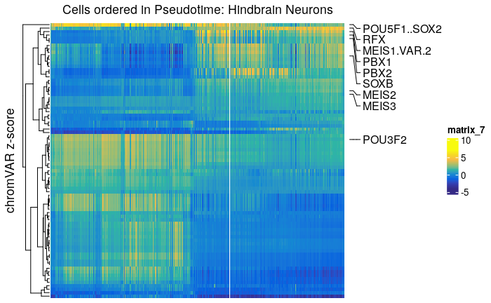

```r
heatmap4
```

```r
# Cell names along Neural 2 trajectory
neural2_cells <- projNC$cellNames[projNC$Clusters %in% c("C4","C7")]

which(projNC$cellNames %in% neural2_cells)
```

[output not shown]

[output cut: 30 more lines]

```r
# Order columns by pseudotime.
neural2_cells_df <- data.frame(Name = neural2_cells,
                           Pseudotime = projNC$hour_adj_pseudotime[projNC$Clusters %in%  c("C4","C7")])

neural2_cells_df <- neural2_cells_df[order(neural2_cells_df$Pseudotime),]

ordered_neural2 <- as.matrix(motif_mat_impute[,neural2_cells_df$Name])

# Filter to only enriched TF's
neural2_Motifs <- getMarkerFeatures(
    ArchRProj = projNC,
    useMatrix = "MotifMatrix",
    groupBy = "Clusters",
    useGroups = c("C4","C7"),
    bias = c("log10(nFrags)"),
    maxCells = 750,
    testMethod = "wilcoxon",
    useSeqnames = "z", threads = 1)
```

```
ArchR logging to : ArchRLogs/ArchR-getMarkerFeatures-8172fa88ff1-Date-2022-06-12_Time-01-11-11.log
If there is an issue, please report to github with logFile!
2022-06-12 01:11:12 : Matching Known Biases, 0.001 mins elapsed.
```

|  | log10(nFrags) | name |
| --- | --- | --- |
| median | 4.2936497 | foreground |
| mean | 4.2379757 | foreground |
| sd | 0.3778778 | foreground |
| lowerQuartile | 3.9999934 | foreground |
| upperQuartile | 4.5189480 | foreground |

|  | log10(nFrags) | name |
| --- | --- | --- |
| median | 4.2941905 | background |
| mean | 4.2381267 | background |
| sd | 0.3776257 | background |
| lowerQuartile | 3.9951170 | background |
| upperQuartile | 4.5192273 | background |

|  | log10(nFrags) | name |
| --- | --- | --- |
| median | 4.3817904 | foreground |
| mean | 4.3143222 | foreground |
| sd | 0.3987508 | foreground |
| lowerQuartile | 4.0596942 | foreground |
| upperQuartile | 4.6247769 | foreground |

|  | log10(nFrags) | name |
| --- | --- | --- |
| median | 4.3805455 | background |
| mean | 4.3142787 | background |
| sd | 0.3987326 | background |
| lowerQuartile | 4.0567331 | background |
| upperQuartile | 4.6251991 | background |

```
2022-06-12 01:11:13 : Computing Pairwise Tests (1 of 2), 0.022 mins elapsed.
```

|  | log2Mean | log2FC | fdr | pval | mean1 | mean2 | n | auc |
| --- | --- | --- | --- | --- | --- | --- | --- | --- |
| f1 | NaN | NaN | 4.397820e-34 | 5.187777e-35 | -0.79850436 | 0.05991442 | 690 | 0.3080676 |
| f2 | NaN | NaN | 4.420913e-72 | 1.837109e-73 | -1.10896181 | 0.05801955 | 690 | 0.2181201 |
| f3 | NaN | NaN | 1.389939e-08 | 5.850412e-09 | -0.17938405 | 0.12577643 | 690 | 0.4094980 |
| f4 | 7.196325 | 2.075109 | 3.315697e-03 | 2.222317e-03 | 0.34211616 | 0.08008487 | 690 | 0.5475572 |
| f5 | 5.864980 | NaN | 9.017208e-01 | 8.882111e-01 | -0.04179029 | 0.20782526 | 690 | 0.4978135 |
| f6 | 7.521190 | 0.726164 | 3.751056e-02 | 2.835919e-02 | 0.33040127 | 0.19915740 | 690 | 0.5340853 |

```
2022-06-12 01:11:16 : Computing Pairwise Tests (2 of 2), 0.067 mins elapsed.
```

|  | log2Mean | log2FC | fdr | pval | mean1 | mean2 | n | auc |
| --- | --- | --- | --- | --- | --- | --- | --- | --- |
| f1 | 3.807555 | NaN | 3.937135e-01 | 3.467423e-01 | 0.05109846 | -0.01624072 | 746 | 0.5140697 |
| f2 | 7.981741 | NaN | 5.130587e-48 | 5.226871e-49 | 0.78211175 | -0.10709702 | 746 | 0.7200081 |
| f3 | 7.215437 | NaN | 2.194720e-13 | 7.060761e-14 | 0.41747106 | -0.02172004 | 746 | 0.6119429 |
| f4 | 6.549519 | 2.69119 | 1.203135e-03 | 7.547814e-04 | 0.21611619 | 0.03232958 | 746 | 0.5503723 |
| f5 | NaN | NaN | 2.759989e-70 | 1.479887e-71 | -1.62501691 | 0.49537314 | 746 | 0.2325468 |
| f6 | NaN | NaN | 2.603723e-55 | 2.373367e-56 | -1.24860751 | 0.40812576 | 746 | 0.2635019 |

```
###########
2022-06-12 01:11:18 : Completed Pairwise Tests, 0.105 mins elapsed.
###########
ArchR logging successful to : ArchRLogs/ArchR-getMarkerFeatures-8172fa88ff1-Date-2022-06-12_Time-01-11-11.log
```

```r
neural2_motif_df <- as.data.frame(getMarkers(neural2_Motifs, cutOff = "FDR <= 1e-15 & MeanDiff > 1.5"))

labels <- c("OTX2_718","Pou5f1..Sox2_38","Dmbx1_366",
            "PITX2_526","SOX2_730","Arid3a_43","PHOX2A_204",
            "Shox2_211","GBX1_372","GATA1_690",
            "PITX3_205","RHOXF1_210")

label_index <- which(unique(neural2_motif_df$name) %in% labels)
label_text <- stringr::str_split(unique(neural2_motif_df$name)[label_index], pattern = "_", simplify = T)[,1]


heatmap5 <- ComplexHeatmap::Heatmap(
  matrix = ordered_neural2[unique(neural2_motif_df$name),],
  cluster_rows = T, cluster_columns = F, show_column_names = F,
  show_row_names = F, use_raster = F, row_title = "chromVAR z-score",
  column_title = "Cells ordered in Pseudotime: Midbrain Neurons",
  col = as.character(ArchRPalettes$blueYellow)) +
  rowAnnotation(names = anno_mark(at = label_index, labels = label_text))

unique(neural2_motif_df$name)[row_order(heatmap5)]
```

```
 [1] "Crx_52"          "OTX2_718"        "GSC_139"         "GSC2_374"        "PITX3_205"       "PITX2_526"
 [7] "PITX1_628"       "Dmbx1_366"       "DPRX_467"        "RFX2_283"        "RFX4_287"        "RFX5_288"
[13] "RFX1_724"        "RFX3_725"        "RHOXF1_210"      "OTX1_202"        "MZF1_711"        "Sox3_72"
[19] "GATA1_690"       "TCF7L2_79"       "Arid3a_43"       "PAX1_268"        "PAX9_270"        "PAX6_14"
[25] "Pou5f1..Sox2_38" "SNAI3_537"       "SNAI1_536"       "TCF12.var.2_656" "TCF3_734"        "TCF4_735"
[31] "SNAI2_729"       "ASCL1.var.2_639" "ZIC1_190"        "ZIC4_240"        "ZIC3_191"        "ZIC5_561"
[37] "Zic2_592"        "Zic1..Zic2_591"  "POU3F4_277"      "POU5F1B_280"     "POU3F2_275"      "POU3F1_274"
[43] "POU1F1_272"      "POU2F3_722"      "POU5F1_402"      "POU2F1_273"      "POU2F2_70"       "POU3F3_276"
[49] "ZEB1_412"        "Rbpjl_585"       "TBX21_184"       "TBX1_295"        "TBX2_182"        "TBX6_545"
[55] "TBX4_296"        "TBX5_297"        "MGA_291"         "TBX15_293"       "Ptf1a.var.3_584"
```

```r
plotPDF(heatmap5, name = "Plot-Midbrain-Neurons-Motif-Pseudotime-Heatmap.pdf", ArchRProj = projNC, addDOC = FALSE, width = 6, height = 5)
```

```
Plotting ComplexHeatmap!
```

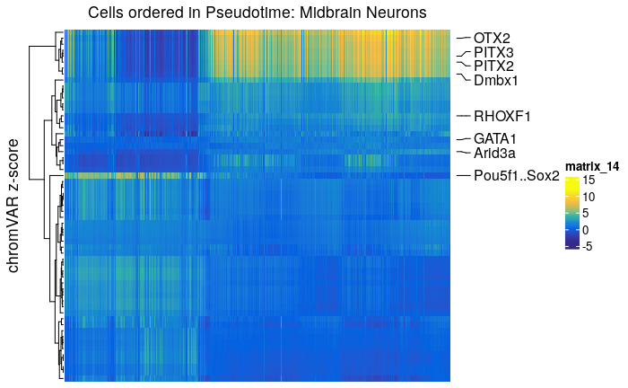

```r
heatmap5
```

```r
heatmap6 <- ComplexHeatmap::Heatmap(
  matrix = ordered_sensory[unique(sensory_motif_df$name),],
  cluster_rows = T, cluster_columns = F, show_column_names = F,
  show_row_names = F, use_raster = F, row_title = "chromVAR z-score",
  column_title = "Cells ordered in Pseudotime: Sensory Glia",
  col = as.character(ArchRPalettes$blueYellow)) +
  rowAnnotation(names = anno_mark(at = label_index, labels = label_text))

unique(sensory_motif_df$name)[row_order(heatmap6)]
```

```
 [1] "Rbpjl_585"        "SNAI1_536"        "SNAI3_537"        "SNAI2_729"        "TCF12.var.2_656"  "TCF3_734"
 [7] "TCF4_735"         "ZEB1_412"         "Ptf1a.var.3_584"  "ASCL1.var.2_639"  "GRHL2_693"        "GRHL1_138"
[13] "FIGLA_311"        "TFAP2A_739"       "TFAP2C.var.2_740" "TFAP2B_300"       "TFAP2C_303"       "TFAP2B.var.2_301"
[19] "TFAP2E_547"       "TFAP2A.var.2_299" "SIX2_406"         "SIX1_405"         "TEAD3_298"        "TEAD4_738"
[25] "TEAD2_409"        "TEAD1_737"        "MYOD1_709"        "TBX4_296"         "TBX5_297"         "SCRT1_727"
[31] "SCRT2_728"        "GATA2_390"        "GATA4_691"        "GATA3_417"        "GATA6_692"        "GATA5_605"
[37] "MGA_291"          "TBX15_293"        "TBX3_544"         "TBX6_545"         "TBX1_295"         "TBX2_182"
[43] "TBR1_292"         "TBX18_543"        "Klf1_62"          "SREBF1.var.2_733" "TFCP2_186"        "GATA1_690"
[49] "ISL2_388"         "TFAP2B.var.3_302" "TFAP2C.var.3_304" "HOXA1_477"        "HOXB5_616"        "HOXA5_613"
[55] "HOXB8_484"        "HOXB7_483"        "HOXA7_480"        "HOXD8_620"        "LHX1_499"         "VAX2_214"
[61] "HOXA6_479"        "HOXC8_487"        "VAX1_213"         "DRGX_468"         "GSX2_608"         "MEOX2_196"
[67] "DLX6_365"         "HOXD3_619"        "HOXB2_615"        "HOXA2_612"        "PDX1_203"         "EMX1_603"
[73] "MEOX1_154"        "EVX2_371"         "EVX1_370"         "Dlx4_364"         "DLX5_464"         "Dlx1_362"
[79] "HOXB6_482"        "Dlx2_368"
```

```r
plotPDF(heatmap6, name = "Plot-Sensory-Glia-Motif-Pseudotime-Heatmap.pdf", ArchRProj = projNC, addDOC = FALSE, width = 6, height = 5)
```

```
Plotting ComplexHeatmap!
```

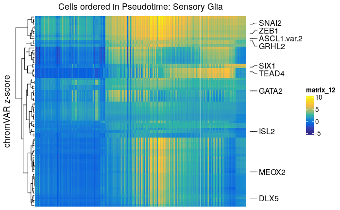

```r
heatmap6
```

```r
plotPDF(heatmap7, name = "Plot-Sensory-neuron-Motif-Pseudotime-Heatmap.pdf", ArchRProj = projNC, addDOC = FALSE, width = 6, height = 5)
```

```
Plotting ComplexHeatmap!
Warning message:
replacing previous import ‘utils::download.file’ by ‘restfulr::download.file’ when loading ‘rtracklayer’
```

```r
heatmap7
```

[output not shown]

[output not shown]

```r
labels <- c("OTX2_718","Pou5f1..Sox2_38","Dmbx1_366",
            "PITX2_526","SOX2_730","Arid3a_43","PHOX2A_204",
            "Shox2_211","GBX1_372","GATA1_690", "GSC_139",
            "PITX3_205","RHOXF1_210","LBX2_193","EN1_128",
            "LHX5_500","TLX2_555","Sox3_72","Msx3_199", "Alx4_338")

label_index <- which(unique(neural3_motif_df$name) %in% labels)
label_text <- stringr::str_split(unique(neural3_motif_df$name)[label_index], pattern = "_", simplify = T)[,1]


heatmap8 <- ComplexHeatmap::Heatmap(
  matrix = ordered_neural3[unique(neural3_motif_df$name),],
  cluster_rows = T, cluster_columns = F, show_column_names = F,
  show_row_names = F, use_raster = F, row_title = "chromVAR z-score",
  column_title = "Cells ordered in Pseudotime: Somatosensory Neurons",
  col = as.character(ArchRPalettes$blueYellow)) +
  rowAnnotation(names = anno_mark(at = label_index, labels = label_text))

unique(neural3_motif_df$name)[row_order(heatmap8)]
```

```
  [1] "Crx_52"           "GSC_139"          "GSC2_374"         "PITX3_205"        "OTX2_718"         "PITX2_526"
  [7] "PITX1_628"        "Dmbx1_366"        "Pou5f1..Sox2_38"  "SNAI3_537"        "SNAI1_536"        "TCF12.var.2_656"
 [13] "TCF3_734"         "TCF4_735"         "ASCL1.var.2_639"  "SNAI2_729"        "ZEB1_412"         "ZIC1_190"
 [19] "ZIC4_240"         "ZIC3_191"         "ZIC5_561"         "Zic2_592"         "Zic1..Zic2_591"   "POU3F2_275"
 [25] "POU3F1_274"       "POU5F1B_280"      "POU3F4_277"       "POU1F1_272"       "POU5F1_402"       "POU2F1_273"
 [31] "POU2F3_722"       "POU2F2_70"        "POU3F3_276"       "Rbpjl_585"        "Ptf1a.var.3_584"  "TBX21_184"
 [37] "TBX4_296"         "TBX5_297"         "TBX1_295"         "TBX2_182"         "TBX6_545"         "MGA_291"
 [43] "TBX15_293"        "LBX2_193"         "GBX1_372"         "EN1_128"          "NOTO_200"         "LHX9_623"
 [49] "TLX2_555"         "PAX4_173"         "Lhx8_195"         "ESX1_131"         "HESX1_376"        "LHX6_152"
 [55] "EMX2_369"         "GBX2_373"         "EN2_129"          "Shox2_211"        "RAX2_208"         "PRRX1_207"
 [61] "SHOX_116"         "ISX_148"          "GSX1_375"         "PRRX2_629"        "BSX_361"          "Msx3_199"
 [67] "MSX1_159"         "MSX2_198"         "Alx4_338"         "POU6F2_281"       "RAX_209"          "Arx_359"
 [73] "Lhx4_194"         "UNCX_212"         "MIXL1_155"        "Alx1_339"         "ARGFX_452"        "DPRX_467"
 [79] "RFX2_283"         "RFX4_287"         "RFX5_288"         "RFX1_724"         "RFX3_725"         "Sox3_72"
 [85] "SOX15_444"        "Sox6_73"          "SOX4_630"         "SOX10_407"        "SOX2_730"         "SOX13_408"
 [91] "SOX9_20"          "SOX8_631"         "MZF1_711"         "RHOXF1_210"       "OTX1_202"         "Sox17_21"
 [97] "SOX18_541"        "SOX14_540"        "HOXB3_382"        "HOXD3_619"        "HOXB2_615"        "HOXA2_612"
[103] "PDX1_203"         "EMX1_603"         "MEOX1_154"        "EVX2_371"         "EVX1_370"         "LBX1_107"
[109] "mix.a_109"        "POU6F1.var.2_528" "NKX6.2_169"       "LHX5_500"         "GSX2_608"         "LHX2_702"
[115] "Dlx3_363"         "ALX3_119"         "VSX1_216"         "VSX2_217"         "Nobox_34"         "PHOX2A_204"
[121] "POU6F1_114"       "NKX6.3_510"       "Hmx1_378"         "NKX6.1_168"       "MNX1_197"         "BARX1_360"
[127] "HOXB7_483"
```

```r
plotPDF(heatmap8, name = "Plot-Somatosensory-Neurons-Motif-Pseudotime-Heatmap.pdf", ArchRProj = projNC, addDOC = FALSE, width = 6, height = 5)
```

```
Plotting ComplexHeatmap!
```

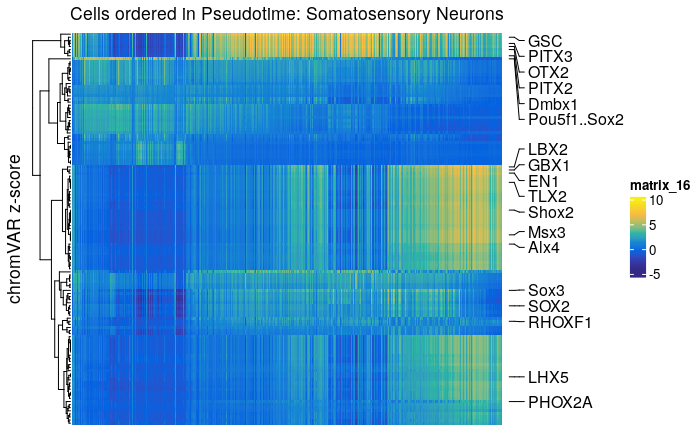

```r
heatmap8
```

```r
unique(melano_motif_df$name)[row_order(heatmap9)]
```

```
  [1] "Pou5f1..Sox2_38"       "POU3F2_275"            "POU3F1_274"            "POU1F1_272"            "POU5F1B_280"
  [6] "POU3F4_277"            "POU2F1_273"            "POU2F3_722"            "POU2F2_70"             "POU5F1_402"
 [11] "POU3F3_276"            "RFX4_287"              "RFX2_283"              "RFX5_288"              "ZIC1_190"
 [16] "ZIC4_240"              "ZIC3_191"              "ZIC5_561"              "TBX4_296"              "TBX5_297"
 [21] "TBX6_545"              "TBX1_295"              "TBX2_182"              "TBX21_184"             "MGA_291"
 [26] "TBX15_293"             "SNAI3_537"             "SNAI2_729"             "TCF12.var.2_656"       "TCF3_734"
 [31] "SNAI1_536"             "TCF4_735"              "ASCL1.var.2_639"       "ZEB1_412"              "Rbpjl_585"
 [36] "Ptf1a.var.3_584"       "Zic2_592"              "Zic1..Zic2_591"        "NFYA_397"              "NFYB_714"
 [41] "SP1_632"               "KLF14_235"             "NFYC_652"              "SP4_177"               "Klf12_237"
 [46] "SP3_634"               "KLF6_498"              "KLF10_492"             "KLF11_493"             "YY1_88"
 [51] "YY2_744"               "ZFP42_659"             "KLF13_151"             "SP8_238"               "Klf1_62"
 [56] "KLF16_236"             "SP9_542"               "KLF2_496"              "SP2_633"               "ELK1_357"
 [61] "ELK3_248"              "FEV_254"               "ETV3_253"              "ELF2_469"              "ELF4_126"
 [66] "CREB3L4.var.2_463"     "FOSL1..JUN.var.2_422"  "JUNB.var.2_622"        "ATF7_321"              "FOSL2..JUNB.var.2_432"
 [71] "FOSB..JUNB.var.2_429"  "Creb5_326"             "JUN..JUNB.var.2_426"   "FOSB..JUN_420"         "JDP2.var.2_150"
 [76] "ATF3_595"              "FOSL1..JUND.var.2_435" "FOSL2..JUN.var.2_424"  "FOSL2..JUND.var.2_437" "CREM_746"
 [81] "ETV5_683"              "ETS2_470"              "ELK4_81"               "ETS1_251"              "FLI1_133"
 [86] "ERF_249"               "ZBTB7A_411"            "ETV6_132"              "ERG_250"               "KLF3_497"
 [91] "Zfx_51"                "TFDP1_410"             "KLF15_494"             "EGR2_227"              "TCFL5_635"
 [96] "NRF1_69"               "EGR3_228"              "EGR4_229"              "SREBF2.var.2_319"      "TFE3_445"
[101] "TFEB_187"              "MLXIPL_157"            "MLX_156"               "KLF5_94"               "KLF4_700"
[106] "EGR1_676"              "HES1_609"              "BHLHE41_122"           "MITF_707"              "Arntl_97"
[111] "ARNT2_453"             "KLF9_701"              "SPDEF_178"             "ZNF740_637"            "VEZF1_556"
[116] "FOS..JUN.var.2_419"    "CREB1_672"             "TFEC_636"              "ELF5_127"              "JUND.var.2_61"
[121] "ATF2_640"              "ETV2_252"              "GLIS2_231"             "RREB1_18"              "KLF17_495"
[126] "PLAG1_48"              "E2F4_602"              "E2F1_351"              "E2F2_600"              "Wt1_590"
[131] "USF2_743"              "BHLHE40_307"           "USF1_742"              "HES2_610"              "Atf1_98"
[136] "CREB3_124"             "ZBTB14_658"            "Creb3l2_101"           "MYCN_394"
```

```r
plotPDF(heatmap9, name = "Plot-Melanocyte-Motif-Pseudotime-Heatmap.pdf", ArchRProj = projNC, addDOC = FALSE, width = 6, height = 5)
```

```
Plotting ComplexHeatmap!
```

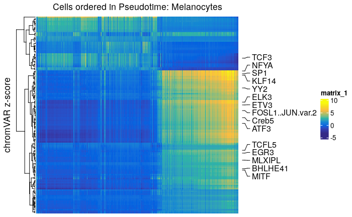

```r
heatmap9
```

## C

Individual line plots of just top Motifs for Mesenchyme branch

```r
# ETS1
p10 <- plotTrajectory(projNC, trajectory = "C10END", colorBy = "MotifMatrix",
                      name = paste0("z:","ETS1_251"), continuousSet = "blueYellow",
                      plotAs = "points", addArrow = F)
```

```
Getting ImputeWeights
ArchR logging to : ArchRLogs/ArchR-plotTrajectory-afa972f37eb2-Date-2022-06-13_Time-23-23-49.log
If there is an issue, please report to github with logFile!
```

|  | IterativeLSI#UMAP_Dimension_1 | IterativeLSI#UMAP_Dimension_2 |
| --- | --- | --- |
| HH12#AGCCTGGTCCACGCTT-1 | 4.4112038 | 2.276715 |
| HH12#TACAGCACAACTACTG-1 | 2.5044708 | 2.088989 |
| HH12#GTCTACCAGGAAGAAC-1 | 4.5683660 | 2.264409 |
| HH12#CGGACTGGTAACGTAA-1 | 2.5286884 | 2.071348 |
| HH12#CTGGGACTCGGTTAGT-1 | 2.6069586 | 2.088019 |
| HH12#TGAGTCAAGGATCCTT-1 | 0.9036467 | 2.563635 |

```
2022-06-13 23:23:54 : Getting Matrix Values...

Imputing Matrix
Plotting
```

|  | x | y | PseudoTime | value |
| --- | --- | --- | --- | --- |
| HH18#CAGTATGCATTGTTCT-1 | 2.3467204 | -1.9649551 | 0.01865672 | 0.3008446 |
| HH18#GACCTTCTCGGTCTAA-1 | 2.2467282 | -1.9174460 | 0.03731343 | 0.3005533 |
| HH12#TACCTATGTGCCCTAG-1 | 0.5881184 | -0.1080996 | 0.05597015 | 1.3780748 |
| HH10#AGCCTGGCATTGTTCT-1 | 0.5482024 | -0.1152584 | 0.07462687 | 1.0297031 |
| HH10#GGAACTTAGCAGGACT-1 | -1.2357314 | -3.5920001 | 0.09328358 | -0.6717082 |
| HH6#GTGTCCTGTTATGCAC-1 | 0.3976822 | -0.3311532 | 0.11194030 | 2.4117217 |

```
ArchR logging successful to : ArchRLogs/ArchR-plotTrajectory-afa972f37eb2-Date-2022-06-13_Time-23-23-49.log
```

```r
plotPDF(p10[[2]], name = "Plot-ETS1-MOTIF-Mesencyme-Pseudotime-Line.pdf",
        ArchRProj = projNC, addDOC = FALSE, width = 6, height = 4)
```

```
Plotting Ggplot!
```

```r
s10 <- plotTrajectory(projNC, trajectory = "C6END", colorBy = "MotifMatrix",
                      name = paste0("z:","PHOX2A_204"), continuousSet = "blueYellow",
                      plotAs = "points", addArrow = F)
```

```
Getting ImputeWeights
ArchR logging to : ArchRLogs/ArchR-plotTrajectory-ec4a5914377d-Date-2022-06-12_Time-14-13-20.log
If there is an issue, please report to github with logFile!
```

|  | IterativeLSI#UMAP_Dimension_1 | IterativeLSI#UMAP_Dimension_2 |
| --- | --- | --- |
| HH12#AGCCTGGTCCACGCTT-1 | 4.4112038 | 2.276715 |
| HH12#TACAGCACAACTACTG-1 | 2.5044708 | 2.088989 |
| HH12#GTCTACCAGGAAGAAC-1 | 4.5683660 | 2.264409 |
| HH12#CGGACTGGTAACGTAA-1 | 2.5286884 | 2.071348 |
| HH12#CTGGGACTCGGTTAGT-1 | 2.6069586 | 2.088019 |
| HH12#TGAGTCAAGGATCCTT-1 | 0.9036467 | 2.563635 |

```
2022-06-12 14:13:25 : Getting Matrix Values...

Imputing Matrix
Plotting
```

|  | x | y | PseudoTime | value |
| --- | --- | --- | --- | --- |
| HH18#AACGGGATCCCTACCA-1 | 5.2877383 | -0.1697843 | 0.03271181 | 0.8068279 |
| HH8#CACAGATGTAGATTAG-1 | 0.6868755 | -1.9761259 | 0.06542362 | -0.7230953 |
| HH10#TTATGTCAGGTTGTTC-1 | 0.5511773 | -1.9163457 | 0.09813543 | -0.7185158 |
| HH8#GCCTAGGGTGGTAGAC-1 | 0.5457554 | -1.9188679 | 0.13084724 | -0.6584906 |
| HH6#TGACTCCAGAGGAAGT-1 | 0.5226923 | -1.9226824 | 0.16355904 | -0.7230708 |
| HH6#AGCGTGCTCTATCTCA-1 | 0.3562959 | -1.8705977 | 0.19627085 | -0.7092365 |

```
ArchR logging successful to : ArchRLogs/ArchR-plotTrajectory-ec4a5914377d-Date-2022-06-12_Time-14-13-20.log
```

```r
plotPDF(s10[[2]], name = "Plot-PHOX2A-MOTIF-Somatosensory-Neurons-Pseudotime-Line.pdf",
        ArchRProj = projNC, addDOC = FALSE, width = 6, height = 4)
```

```
Plotting Ggplot!
```

## D

# Figure 3

Genescores

## A

Investigation of Genescores.

TODO - Genescores using this new algorithm seems worse than previous implemention from Cicero. Perhaps I should compare Cicero vs ArchR Coaccessibility 1. It seems that ArchR gives ‘cleaner’ CoAccessibility.

```r
plotMarkerHeatmap(seMarker = markersGS, cutOff = "FDR <= 0.1 & Log2FC >= 1",
                  nLabel = 5, plotLog2FC = T, grepExclude = "NA", transpose = T,
                  pal = ArchRPalettes$horizonExtra)
```

```
ArchR logging to : ArchRLogs/ArchR-plotMarkerHeatmap-d87d7abd5b9e-Date-2022-06-16_Time-16-25-29.log
If there is an issue, please report to github with logFile!
Printing Top Marker Genes:
C2:
    1:LOC112532775, 1:LOC107050394, 1:VEGFD, 1:ART7C, 1:OR52R1, 11:LOC112533310, 12:OGN, 13:LOC112533403, 13:ARSI, 13:SLC6A7, 13:COL23A1, 16:CLC2BL1, 18:LOC112530016, 25:LOC100859586, 25:LOC101751678
C3:
    10:MESP2, 1:MIR6629, 1:MIR1460, 1:MLC1, 1:MIR1645, 1:CTSEAL, 1:KERA, 1:LUM, 1:SOX10, 1:LOC112532775, 1:NOBOX, 1:KEL, 1:TRPV6, 1:LOC107050394, 1:UPK1B
C4:
    1:MIR1460, 1:MLC1, 1:MIR1645, 1:CTSEAL, 1:KERA, 1:LUM, 1:SOX10, 1:LOC418544, 1:BMX, 12:MIR1550, 18:CYGB, 19:SBDS, 19:CCL1, 19:CCL26, 21:NPPA
C5:
    1:MIR6629, 1:UPK1B, 15:CRYBB2, 19:CLDN3, 2:LOC425781, 25:S100A11, 25:EDCH3, 26:SLC26A9, 3:LOC107053057, 4:MIR6704, 4:MIR302B, 4:MIR302C, 4:MIR1811, NA, NA
C6:
    25:LOC100859616, 27:HOXB4, 4:ADAM33, 5:MIR1578, 6:LIPML2, NA, NA, NA, NA, NA, NA, NA, NA, NA, NA
C7:
    22:BMP10, 25:LOC100859657, 25:LOC100859722, 25:LOC107055125, 27:DLX4, 27:HOXB6, 4:SASH3, 4:IL13RA2, Z:LOC101750948, Z:MIR1452, NA, NA, NA, NA, NA
C8:
    1:ART7B, 16:LOC107049095, 19:DPH1, 2:LOC100857382, 2:LOC107052804, 25:LOC769486, 25:LOC770126, 26:MIRLET7A1, 28:CFD, 28:GDF3, 4:LOC112532455, 4:SEPTIN11, NA, NA, NA
C9:
    13:CDX1, 14:OCM2, 14:VASN, 18:MIR1748, 2:GJC2, 2:HOXA2, 2:LOC101748775, 20:UBE2V1, 25:LOC408038, 25:LOC426218, 25:LOC430661, 25:LOC771082, 25:EDCH2, 25:KRTAP10-4, 30:ILF3
C10:
    1:NOBOX, 1:KEL, 1:TRPV6, 1:ZDHHC23, 1:STX19, 1:LOC112531640, 1:LRRC32, 1:ART1, 10:GNRHR, 10:MESP1, 13:LOC101750644, 15:DGCR6, 15:SCARF2, 17:ENTPD2L, 17:MIR6696
Identified 223 markers!
```

```
 [1] "1:LOC112532775"  "1:LOC107050394"  "1:VEGFD"         "1:ART7C"         "1:OR52R1"
 [6] "10:MESP2"        "1:MIR6629"       "1:MIR1460"       "1:MLC1"          "1:MIR1645"
[11] "1:CTSEAL"        "1:KERA"          "1:UPK1B"         "15:CRYBB2"       "19:CLDN3"
[16] "2:LOC425781"     "25:LOC100859616" "27:HOXB4"        "4:ADAM33"        "5:MIR1578"
[21] "6:LIPML2"        "22:BMP10"        "25:LOC100859657" "25:LOC100859722" "25:LOC107055125"
[26] "27:DLX4"         "1:ART7B"         "16:LOC107049095" "19:DPH1"         "2:LOC100857382"
[31] "2:LOC107052804"  "13:CDX1"         "14:OCM2"         "14:VASN"         "18:MIR1748"
[36] "2:GJC2"          "1:NOBOX"         "1:KEL"           "1:TRPV6"         "1:ZDHHC23"
[41] "1:STX19"
```

[output not shown]

## B

DiffTF-like correlation of TF expression to accessibility of peaks that contain their motif.

We can use this to identify transcription factors of interest in each lineage. Interested in FOXD3 ‘biomodal’ activity.

```r
seGroupMotif <- getGroupSE(ArchRProj = projNC, useMatrix = "MotifMatrix", groupBy = "Clusters")
```

```
ArchR logging to : ArchRLogs/ArchR-getGroupSE-379331065740-Date-2022-06-14_Time-22-51-17.log
If there is an issue, please report to github with logFile!
2022-06-14 22:51:25 : Constructing Group Matrix 1 of 1, 0.001 mins elapsed.
2022-06-14 22:51:32 : Finished Group Matrix 1 of 1, 0.119 mins elapsed.
2022-06-14 22:51:32 : Successfully Created Group Matrix, 0.119 mins elapsed.
ArchR logging successful to : ArchRLogs/ArchR-getGroupSE-379331065740-Date-2022-06-14_Time-22-51-17.log
```

```r
seZ <- seGroupMotif[rowData(seGroupMotif)$seqnames=="z",]

rowData(seZ)$maxDelta <- lapply(seq_len(ncol(seZ)), function(x){
  rowMaxs(assay(seZ) - assay(seZ)[,x])
}) %>% Reduce("cbind", .) %>% rowMaxs

corGSM_MM <- correlateMatrices(
    ArchRProj = projNC,
    useMatrix1 = "GeneScoreMatrix",
    useMatrix2 = "MotifMatrix",
    reducedDims = "IterativeLSI")
```

```
ArchR logging to : ArchRLogs/ArchR-correlateMatrices-37933f0e86f5-Date-2022-06-14_Time-22-51-35.log
If there is an issue, please report to github with logFile!
2022-06-14 22:51:45 : Testing 503 Mappings!, 0.157 mins elapsed.
2022-06-14 22:51:45 : Computing KNN, 0.157 mins elapsed.
2022-06-14 22:51:45 : Identifying Non-Overlapping KNN pairs, 0.16 mins elapsed.
2022-06-14 22:51:46 : Identified 493 Groupings!, 0.183 mins elapsed.
2022-06-14 22:51:48 : Getting Group Matrix 1, 0.218 mins elapsed.
2022-06-14 22:52:02 : Getting Group Matrix 2, 0.444 mins elapsed.
2022-06-14 22:52:08 : Getting Correlations...
```

|  | cor | pval | padj |
| --- | --- | --- | --- |
| 1 | 0.12252134 | 6.453980e-03 | 1.000000e+00 |
| 2 | -0.10242047 | 2.294709e-02 | 1.000000e+00 |
| 3 | -0.03620293 | 4.225195e-01 | 1.000000e+00 |
| 4 | -0.49206547 | 2.005231e-31 | 1.008631e-28 |
| 5 | 0.11656409 | 9.586209e-03 | 1.000000e+00 |
| 6 | -0.10619730 | 1.834153e-02 | 1.000000e+00 |

```
ArchR logging successful to : ArchRLogs/ArchR-correlateMatrices-37933f0e86f5-Date-2022-06-14_Time-22-51-35.log
```

```r
corGSM_MM$maxDelta <- rowData(seZ)[match(corGSM_MM$MotifMatrix_name, rowData(seZ)$name), "maxDelta"]

corGSM_MM <- corGSM_MM[order(abs(corGSM_MM$cor), decreasing = TRUE), ]
corGSM_MM <- corGSM_MM[which(!duplicated(gsub("\\-.*","",corGSM_MM[,"MotifMatrix_name"]))), ]
corGSM_MM$TFRegulator <- "NO"

# Positive
corGSM_MM$TFRegulator[which(corGSM_MM$cor > 0.3 & corGSM_MM$padj < 0.1 & corGSM_MM$maxDelta > quantile(corGSM_MM$maxDelta, 0.7))] <- "Positive"
# Negative
corGSM_MM$TFRegulator[which(corGSM_MM$cor < -0.3 & corGSM_MM$padj < 0.1 & corGSM_MM$maxDelta > quantile(corGSM_MM$maxDelta, 0.7))] <- "Negative"

sort(corGSM_MM[corGSM_MM$TFRegulator=="Positive",1])
```

```
 [1] "ARX"    "ATOH7"  "DMBX1"  "EMX2"   "ERG"    "ESX1"   "ETS1"   "ETV1"   "ETV3"   "FLI1"   "FOXC1"  "FOXC2"  "FOXF1"
[14] "FOXK1"  "GSC2"   "HESX1"  "KLF11"  "LHX4"   "LHX9"   "NFYA"   "NFYC"   "NOTO"   "NR2F1"  "NR2F2"  "OTX2"   "PITX2"
[27] "POU3F2" "PPARD"  "RARB"   "RAX"    "RAX2"   "RFX2"   "RFX4"   "RXRA"   "SIX1"   "SOX13"  "SOX14"  "SOX2"   "SOX3"
[40] "SP1"    "SP2"    "SP4"    "TEAD3"  "TFAP2A" "TFAP2E" "TWIST1" "TWIST2" "YY2"    "ZBTB7A"
```

```r
corGSM_MM$label <- ifelse(corGSM_MM$TFRegulator %in% c("Positive","Negative"), corGSM_MM$GeneScoreMatrix_name, "")

p13 <- ggplot(data.frame(corGSM_MM), aes(cor, maxDelta, color = TFRegulator, label = label)) +
  geom_point() +
  theme_ArchR() +
  geom_vline(xintercept = 0, lty = "dashed") +
  scale_color_manual(values = c("NO"="darkgrey", "Positive"="firebrick3", "Negative"="blue")) +
  xlab("Correlation To Gene Score") +
  ylab("Max TF Motif Delta") +
  scale_y_continuous(
    expand = c(0,0),
    limits = c(0, max(corGSM_MM$maxDelta)*1.05)
  ) + geom_label_repel(max.overlaps = 20, box.padding = 0.25)

plotPDF(p13, name = "Plot-DiffTFlike-GeneScore-TF-Correlation.pdf", ArchRProj = projNC, addDOC = FALSE, width = 6, height = 7)
```

```
Plotting Ggplot!
Warning: ggrepel: 38 unlabeled data points (too many overlaps). Consider increasing max.overlaps
```

[figure not shown]

```r
p13
```

```r
write_csv(corGSM_MM, "DiffTFlike-GeneScore-TF-Correlation-Table.csv")
```

```
Error in write_delim(x, file, delim = ",", na = na, append = append, col_names = col_names,  :
  is.data.frame(x) is not TRUE
```

```r
# Mesenchyme
projNC_mes <- projNC[projNC$Cell_Identity %in%
                       c("C4_Multipotent_NC","C8_Early_Mesenchyme",
                         "C3_Int_Mesenchyme","C10_Late_Mesenchyme"),]


seGroupMotif_mes <- getGroupSE(ArchRProj = projNC_mes, useMatrix = "MotifMatrix", groupBy = "Clusters")
seZ_mes <- seGroupMotif_mes[rowData(seGroupMotif_mes)$seqnames=="z",]

rowData(seZ_mes)$maxDelta <- lapply(seq_len(ncol(seZ_mes)), function(x){
  rowMaxs(assay(seZ_mes) - assay(seZ_mes)[,x])
}) %>% Reduce("cbind", .) %>% rowMaxs

corGSM_MM_mes <- correlateMatrices(
    ArchRProj = projNC_mes,
    useMatrix1 = "GeneScoreMatrix",
    useMatrix2 = "MotifMatrix",
    reducedDims = "IterativeLSI")

corGSM_MM_mes$maxDelta <- rowData(seZ_mes)[match(corGSM_MM_mes$MotifMatrix_name, rowData(seZ_mes)$name), "maxDelta"]

corGSM_MM_mes <- corGSM_MM_mes[order(abs(corGSM_MM_mes$cor), decreasing = TRUE), ]
corGSM_MM_mes <- corGSM_MM_mes[which(!duplicated(gsub("\\-.*","",corGSM_MM_mes[,"MotifMatrix_name"]))), ]
corGSM_MM_mes$TFRegulator <- "NO"

# Positive
corGSM_MM_mes$TFRegulator[which(corGSM_MM_mes$cor > 0.3 & corGSM_MM_mes$padj < 0.1 & corGSM_MM_mes$maxDelta > quantile(corGSM_MM_mes$maxDelta, 0.7))] <- "Positive"
# Negative
corGSM_MM_mes$TFRegulator[which(corGSM_MM_mes$cor < -0.3 & corGSM_MM_mes$padj < 0.1 & corGSM_MM_mes$maxDelta > quantile(corGSM_MM_mes$maxDelta, 0.7))] <- "Negative"

sort(corGSM_MM_mes[corGSM_MM_mes$TFRegulator=="Positive",1])

corGSM_MM_mes$label <- ifelse(corGSM_MM_mes$TFRegulator %in% c("Positive","Negative"), corGSM_MM_mes$GeneScoreMatrix_name, "")

p14 <- ggplot(data.frame(corGSM_MM_mes), aes(cor, maxDelta, color = TFRegulator, label = label)) +
  geom_point() +
  theme_ArchR() +
  geom_vline(xintercept = 0, lty = "dashed") +
  scale_color_manual(values = c("NO"="darkgrey", "Positive"="firebrick3", "Negative"="blue")) +
  xlab("Correlation To Gene Score") +
  ylab("Max TF Motif Delta") +
  scale_y_continuous(
    expand = c(0,0),
    limits = c(0, max(corGSM_MM_mes$maxDelta)*1.05)
  ) + geom_label_repel(max.overlaps = 20, box.padding = 0.25)

plotPDF(p14, name = "Plot-Mesencyme-GeneScore-TF-Correlation.pdf", ArchRProj = projNC, addDOC = FALSE, width = 6, height = 7)

p14

projNC_senseNeuron <- projNC[projNC$Cell_Identity %in%
                       c("C4_Multipotent_NC","C9_Sensory_Neurons"),]


seGroupMotif_senseNeuron <- getGroupSE(ArchRProj = projNC_senseNeuron, useMatrix = "MotifMatrix", groupBy = "Clusters")
seZ_senseNeuron <- seGroupMotif_senseNeuron[rowData(seGroupMotif_senseNeuron)$seqnames=="z",]

rowData(seZ_senseNeuron)$maxDelta <- lapply(seq_len(ncol(seZ_senseNeuron)), function(x){
  rowMaxs(assay(seZ_senseNeuron) - assay(seZ_senseNeuron)[,x])
}) %>% Reduce("cbind", .) %>% rowMaxs

corGSM_MM_senseNeuron <- correlateMatrices(
    ArchRProj = projNC_senseNeuron,
    useMatrix1 = "GeneScoreMatrix",
    useMatrix2 = "MotifMatrix",
    reducedDims = "IterativeLSI")

corGSM_MM_senseNeuron$maxDelta <- rowData(seZ_senseNeuron)[match(corGSM_MM_senseNeuron$MotifMatrix_name, rowData(seZ_senseNeuron)$name), "maxDelta"]

corGSM_MM_senseNeuron <- corGSM_MM_senseNeuron[order(abs(corGSM_MM_senseNeuron$cor), decreasing = TRUE), ]
corGSM_MM_senseNeuron <- corGSM_MM_senseNeuron[which(!duplicated(gsub("\\-.*","",corGSM_MM_senseNeuron[,"MotifMatrix_name"]))), ]
corGSM_MM_senseNeuron$TFRegulator <- "NO"

# Positive
corGSM_MM_senseNeuron$TFRegulator[which(corGSM_MM_senseNeuron$cor > 0.3 & corGSM_MM_senseNeuron$padj < 0.1 & corGSM_MM_senseNeuron$maxDelta > quantile(corGSM_MM_senseNeuron$maxDelta, 0.7))] <- "Positive"
# Negative
corGSM_MM_senseNeuron$TFRegulator[which(corGSM_MM_senseNeuron$cor < -0.3 & corGSM_MM_senseNeuron$padj < 0.1 & corGSM_MM_senseNeuron$maxDelta > quantile(corGSM_MM_senseNeuron$maxDelta, 0.7))] <- "Negative"

sort(corGSM_MM_senseNeuron[corGSM_MM_senseNeuron$TFRegulator=="Positive",1])

corGSM_MM_senseNeuron$label <- ifelse(corGSM_MM_senseNeuron$TFRegulator %in% c("Positive","Negative"), corGSM_MM_senseNeuron$GeneScoreMatrix_name, "")

p15 <- ggplot(data.frame(corGSM_MM_senseNeuron), aes(cor, maxDelta, color = TFRegulator, label = label)) +
  geom_point() +
  theme_ArchR() +
  geom_vline(xintercept = 0, lty = "dashed") +
  scale_color_manual(values = c("NO"="darkgrey", "Positive"="firebrick3", "Negative"="blue")) +
  xlab("Correlation To Gene Score") +
  ylab("Max TF Motif Delta") +
  scale_y_continuous(
    expand = c(0,0),
    limits = c(0, max(corGSM_MM_senseNeuron$maxDelta)*1.05)
  ) + geom_label_repel(max.overlaps = 20, box.padding = 0.25)

plotPDF(p15, name = "Plot-SensoryNeuron-GeneScore-TF-Correlation.pdf", ArchRProj = projNC, addDOC = FALSE, width = 6, height = 7)

p15

# What are the largest differences between shared transcription factors?
# First, see how many are classified differently.

mes_summary <- as.data.frame(corGSM_MM_mes[corGSM_MM_mes$TFRegulator %in% c("Positive","Negative"), c("cor","label")])

sn_summary <- as.data.frame(corGSM_MM_senseNeuron[corGSM_MM_senseNeuron$TFRegulator %in% c("Positive","Negative"), c("cor","label")])

correlation_comparison <- merge(mes_summary, sn_summary, by = "label", all.x = TRUE, all.y = TRUE)
```

## E

Integrative pseudo-time analyses. Let’s find the best correlated Gene to Motif scores in an unbaised way.

```r
# For each lineage, find the best correlated TF+Genes

for(lineage in c("C1END","C2END","C5END","C6END","C7END","C9END","C10END")){
  END_MM  <- getTrajectory(ArchRProj = projNC, name = lineage, useMatrix = "MotifMatrix", log2Norm = FALSE)
  END_GSM <- getTrajectory(ArchRProj = projNC, name = lineage, useMatrix = "GeneScoreMatrix", log2Norm = FALSE)
  END_MM_corGSM_MM <- correlateTrajectories(END_MM, END_GSM, corCutOff = 0.4)

  END_trajGSM2 <- END_GSM[END_MM_corGSM_MM[[1]]$name2, ]
  END_trajMM2 <- END_MM[END_MM_corGSM_MM[[1]]$name1, ]
  trajCombined <- END_trajGSM2
  assay(trajCombined, withDimnames = F) <- t(apply(assay(END_trajGSM2), 1, scale)) + t(apply(assay(END_trajMM2), 1, scale))
  combinedMat <- plotTrajectoryHeatmap(trajCombined, returnMat = TRUE, varCutOff = 0)
  rowOrder <- match(rownames(combinedMat), rownames(END_trajGSM2))
  ht1 <- plotTrajectoryHeatmap(END_trajGSM2,  pal = paletteContinuous(set = "horizonExtra"),  varCutOff = 0, rowOrder = rowOrder)
  ht2 <- plotTrajectoryHeatmap(END_trajMM2, pal = paletteContinuous(set = "solarExtra"), varCutOff = 0, rowOrder = rowOrder)
  combined_cor_heatmap <- ht1 + ht2
  plotPDF(combined_cor_heatmap, name = paste0(lineage,"_TF-Gene_Correlation.pdf"), ArchRProj = projNC,
           addDOC = FALSE)
}

# This was a great initial pass. After a bunch of literature review, let's focus on the highlighted factors.

# Mesenchyme focus
END_MM  <- getTrajectory(ArchRProj = projNC, name = "C10END", useMatrix = "MotifMatrix", log2Norm = FALSE)
END_GSM <- getTrajectory(ArchRProj = projNC, name = "C10END", useMatrix = "GeneScoreMatrix", log2Norm = FALSE)
END_MM_corGSM_MM <- correlateTrajectories(END_MM, END_GSM, corCutOff = 0.1, varCutOff1 = 0.6, varCutOff2 = 0.6, maxDist = 500000)

# Filter for TF's of interest
mes_tfs <- c("z:ZBTB18_192","z:TWIST1_741","z:TFAP2B_300","z:NR2F1_220","z:ETS1_251","z:FLI1_133")
END_MM_corGSM_MM_filt <- END_MM_corGSM_MM[[1]][END_MM_corGSM_MM$correlatedMappings$name1 %in% mes_tfs,]

END_trajGSM2 <- END_GSM[END_MM_corGSM_MM_filt$name2, ]
END_trajMM2 <- END_MM[END_MM_corGSM_MM_filt$name1, ]
trajCombined <- END_trajGSM2
assay(trajCombined, withDimnames = F) <- t(apply(assay(END_trajGSM2), 1, scale)) + t(apply(assay(END_trajMM2), 1, scale))


combinedMat <- plotTrajectoryHeatmap(trajCombined, returnMat = TRUE, varCutOff = 0)

rowOrder <- match(rownames(combinedMat), rownames(END_trajGSM2))
ht1 <- plotTrajectoryHeatmap(END_trajGSM2,  pal = paletteContinuous(set = "horizonExtra"),  varCutOff = 0, rowOrder = rowOrder)
ht2 <- plotTrajectoryHeatmap(END_trajMM2, pal = paletteContinuous(set = "solarExtra"), varCutOff = 0, rowOrder = rowOrder)

combined_cor_heatmap <- ht1 + ht2

plotPDF(combined_cor_heatmap, name = paste0("Mesenchyme_TF-Gene_Correlation_Heatmap.pdf"), ArchRProj = projNC,
           addDOC = FALSE)

# Sensory Glia Focus
END_MM  <- getTrajectory(ArchRProj = projNC, name = "C2END", useMatrix = "MotifMatrix", log2Norm = FALSE)
END_GSM <- getTrajectory(ArchRProj = projNC, name = "C2END", useMatrix = "GeneScoreMatrix", log2Norm = FALSE)
END_MM_corGSM_MM <- correlateTrajectories(END_MM, END_GSM, corCutOff = 0.1, varCutOff1 = 0.6, varCutOff2 = 0.6, maxDist = 500000)

# Filter for TF's of interest
sensory_glia_factors <- c("z:SIX1_405","z:DLX5_464","z:ZEB1_412","z:SNAI2_729","z:GATA2_390","z:ZIC5_561")

END_MM_corGSM_MM_filt <- END_MM_corGSM_MM[[1]][END_MM_corGSM_MM$correlatedMappings$name1 %in% sensory_glia_factors,]
END_trajGSM2 <- END_GSM[END_MM_corGSM_MM_filt$name2, ]
END_trajMM2 <- END_MM[END_MM_corGSM_MM_filt$name1, ]
trajCombined <- END_trajGSM2
assay(trajCombined, withDimnames = F) <- t(apply(assay(END_trajGSM2), 1, scale)) + t(apply(assay(END_trajMM2), 1, scale))
combinedMat <- plotTrajectoryHeatmap(trajCombined, returnMat = TRUE, varCutOff = 0)
rowOrder <- match(rownames(combinedMat), rownames(END_trajGSM2))
ht1 <- plotTrajectoryHeatmap(END_trajGSM2,  pal = paletteContinuous(set = "horizonExtra"),  varCutOff = 0, rowOrder = rowOrder)
ht2 <- plotTrajectoryHeatmap(END_trajMM2, pal = paletteContinuous(set = "solarExtra"), varCutOff = 0, rowOrder = rowOrder)
combined_cor_heatmap <- ht1 + ht2

plotPDF(combined_cor_heatmap, name = paste0("Sensory_Glia_TF-Gene_Correlation_Heatmap.pdf"), ArchRProj = projNC,
           addDOC = FALSE)

# Sensory Neuron Focus
END_MM  <- getTrajectory(ArchRProj = projNC, name = "C9END", useMatrix = "MotifMatrix", log2Norm = FALSE)
END_GSM <- getTrajectory(ArchRProj = projNC, name = "C9END", useMatrix = "GeneScoreMatrix", log2Norm = FALSE)
END_MM_corGSM_MM <- correlateTrajectories(END_MM, END_GSM, corCutOff = 0.1, varCutOff1 = 0.2, varCutOff2 = 0.2, maxDist = 500000)

# Filter for TF's of interest
sensory_neuron_factors <- c("z:GATA5_605","z:FOXP1_688","z:SOX10_407","z:ZIC5_561","z:SIX1_405","z:FOXC2_333")

END_MM_corGSM_MM_filt <- END_MM_corGSM_MM[[1]][END_MM_corGSM_MM$correlatedMappings$name1 %in% sensory_neuron_factors,]
END_trajGSM2 <- END_GSM[END_MM_corGSM_MM_filt$name2, ]
END_trajMM2 <- END_MM[END_MM_corGSM_MM_filt$name1, ]
trajCombined <- END_trajGSM2
assay(trajCombined, withDimnames = F) <- t(apply(assay(END_trajGSM2), 1, scale)) + t(apply(assay(END_trajMM2), 1, scale))
combinedMat <- plotTrajectoryHeatmap(trajCombined, returnMat = TRUE, varCutOff = 0)
rowOrder <- match(rownames(combinedMat), rownames(END_trajGSM2))
ht1 <- plotTrajectoryHeatmap(END_trajGSM2,  pal = paletteContinuous(set = "horizonExtra"),  varCutOff = 0, rowOrder = rowOrder)
ht2 <- plotTrajectoryHeatmap(END_trajMM2, pal = paletteContinuous(set = "solarExtra"), varCutOff = 0, rowOrder = rowOrder)
combined_cor_heatmap <- ht1 + ht2

plotPDF(combined_cor_heatmap, name = paste0("Sensory_Neurons_TF-Gene_Correlation_Heatmap.pdf"), ArchRProj = projNC,
           addDOC = FALSE)

# Melanocyte Focus
END_MM  <- getTrajectory(ArchRProj = projNC, name = "C1END", useMatrix = "MotifMatrix", log2Norm = FALSE)
END_GSM <- getTrajectory(ArchRProj = projNC, name = "C1END", useMatrix = "GeneScoreMatrix", log2Norm = FALSE)
END_MM_corGSM_MM <- correlateTrajectories(END_MM, END_GSM, corCutOff = 0.1, varCutOff1 = 0.2, varCutOff2 = 0.2, maxDist = 500000)

# Filter for TF's of interest
melano_factors <- c("z:NFYA_397","z:KLF11_493","z:SP1_632","z:YY2_744","z:ETV3_253","z:ATF2_640")

END_MM_corGSM_MM_filt <- END_MM_corGSM_MM[[1]][END_MM_corGSM_MM$correlatedMappings$name1 %in% melano_factors,]
END_trajGSM2 <- END_GSM[END_MM_corGSM_MM_filt$name2, ]
END_trajMM2 <- END_MM[END_MM_corGSM_MM_filt$name1, ]
trajCombined <- END_trajGSM2
assay(trajCombined, withDimnames = F) <- t(apply(assay(END_trajGSM2), 1, scale)) + t(apply(assay(END_trajMM2), 1, scale))
combinedMat <- plotTrajectoryHeatmap(trajCombined, returnMat = TRUE, varCutOff = 0)
rowOrder <- match(rownames(combinedMat), rownames(END_trajGSM2))
ht1 <- plotTrajectoryHeatmap(END_trajGSM2,  pal = paletteContinuous(set = "horizonExtra"),  varCutOff = 0, rowOrder = rowOrder)
ht2 <- plotTrajectoryHeatmap(END_trajMM2, pal = paletteContinuous(set = "solarExtra"), varCutOff = 0, rowOrder = rowOrder)
combined_cor_heatmap <- ht1 + ht2

plotPDF(combined_cor_heatmap, name = paste0("Melanocyte_TF-Gene_Correlation_Heatmap.pdf"), ArchRProj = projNC,
           addDOC = FALSE)


# Hindbrain Neuron Focus
END_MM  <- getTrajectory(ArchRProj = projNC, name = "C5END", useMatrix = "MotifMatrix", log2Norm = FALSE)
END_GSM <- getTrajectory(ArchRProj = projNC, name = "C5END", useMatrix = "GeneScoreMatrix", log2Norm = FALSE)
END_MM_corGSM_MM <- correlateTrajectories(END_MM, END_GSM, corCutOff = 0.1, varCutOff1 = 0.2, varCutOff2 = 0.2, maxDist = 500000)

# Filter for TF's of interest
hindbrain_factors <- c("z:RFX4_287","z:MEIS1_261","z:SOX2_730","z:MEIS2_262","z:RFX2_283","z:RFX3_725")

END_MM_corGSM_MM_filt <- END_MM_corGSM_MM[[1]][END_MM_corGSM_MM$correlatedMappings$name1 %in% hindbrain_factors,]
END_trajGSM2 <- END_GSM[END_MM_corGSM_MM_filt$name2, ]
END_trajMM2 <- END_MM[END_MM_corGSM_MM_filt$name1, ]
trajCombined <- END_trajGSM2
assay(trajCombined, withDimnames = F) <- t(apply(assay(END_trajGSM2), 1, scale)) + t(apply(assay(END_trajMM2), 1, scale))
combinedMat <- plotTrajectoryHeatmap(trajCombined, returnMat = TRUE, varCutOff = 0)
rowOrder <- match(rownames(combinedMat), rownames(END_trajGSM2))
ht1 <- plotTrajectoryHeatmap(END_trajGSM2,  pal = paletteContinuous(set = "horizonExtra"),  varCutOff = 0, rowOrder = rowOrder)
ht2 <- plotTrajectoryHeatmap(END_trajMM2, pal = paletteContinuous(set = "solarExtra"), varCutOff = 0, rowOrder = rowOrder)
combined_cor_heatmap <- ht1 + ht2

plotPDF(combined_cor_heatmap, name = paste0("Hindbrain_Neurons_TF-Gene_Correlation_Heatmap.pdf"), ArchRProj = projNC,
           addDOC = FALSE)

# Midbrain Neuron Focus
END_MM  <- getTrajectory(ArchRProj = projNC, name = "C7END", useMatrix = "MotifMatrix", log2Norm = FALSE)
END_GSM <- getTrajectory(ArchRProj = projNC, name = "C7END", useMatrix = "GeneScoreMatrix", log2Norm = FALSE)
END_MM_corGSM_MM <- correlateTrajectories(END_MM, END_GSM, corCutOff = 0.1, varCutOff1 = 0.2, varCutOff2 = 0.2, maxDist = 500000)

# Filter for TF's of interest
midbrain_factors <- c("z:OTX2_718","z:GATA4_691","z:GLI3_474","z:RFX4_287","z:PAX7_174","z:TBX6_545")

END_MM_corGSM_MM_filt <- END_MM_corGSM_MM[[1]][END_MM_corGSM_MM$correlatedMappings$name1 %in% midbrain_factors,]
END_trajGSM2 <- END_GSM[END_MM_corGSM_MM_filt$name2, ]
END_trajMM2 <- END_MM[END_MM_corGSM_MM_filt$name1, ]
trajCombined <- END_trajGSM2
assay(trajCombined, withDimnames = F) <- t(apply(assay(END_trajGSM2), 1, scale)) + t(apply(assay(END_trajMM2), 1, scale))
combinedMat <- plotTrajectoryHeatmap(trajCombined, returnMat = TRUE, varCutOff = 0)
rowOrder <- match(rownames(combinedMat), rownames(END_trajGSM2))
ht1 <- plotTrajectoryHeatmap(END_trajGSM2,  pal = paletteContinuous(set = "horizonExtra"),  varCutOff = 0, rowOrder = rowOrder)
ht2 <- plotTrajectoryHeatmap(END_trajMM2, pal = paletteContinuous(set = "solarExtra"), varCutOff = 0, rowOrder = rowOrder)
combined_cor_heatmap <- ht1 + ht2

plotPDF(combined_cor_heatmap, name = paste0("Midbrain_Neurons_TF-Gene_Correlation_Heatmap.pdf"), ArchRProj = projNC,
           addDOC = FALSE)

# Somatosensory Neuron Focus
END_MM  <- getTrajectory(ArchRProj = projNC, name = "C5END", useMatrix = "MotifMatrix", log2Norm = FALSE)
END_GSM <- getTrajectory(ArchRProj = projNC, name = "C5END", useMatrix = "GeneScoreMatrix", log2Norm = FALSE)
END_MM_corGSM_MM <- correlateTrajectories(END_MM, END_GSM, corCutOff = 0.1, varCutOff1 = 0.1, varCutOff2 = 0.1, maxDist = 500000)

# Filter for TF's of interest
somato_factors <- c("z:RFX4_287","z:SOX2_730","z:OTX2_718","z:LHX5_500","z:MEIS1_261","z:BHLHE40_307")

END_MM_corGSM_MM_filt <- END_MM_corGSM_MM[[1]][END_MM_corGSM_MM$correlatedMappings$name1 %in% somato_factors,]
END_trajGSM2 <- END_GSM[END_MM_corGSM_MM_filt$name2, ]
END_trajMM2 <- END_MM[END_MM_corGSM_MM_filt$name1, ]
trajCombined <- END_trajGSM2
assay(trajCombined, withDimnames = F) <- t(apply(assay(END_trajGSM2), 1, scale)) + t(apply(assay(END_trajMM2), 1, scale))
combinedMat <- plotTrajectoryHeatmap(trajCombined, returnMat = TRUE, varCutOff = 0)
rowOrder <- match(rownames(combinedMat), rownames(END_trajGSM2))
ht1 <- plotTrajectoryHeatmap(END_trajGSM2,  pal = paletteContinuous(set = "horizonExtra"),  varCutOff = 0, rowOrder = rowOrder)
ht2 <- plotTrajectoryHeatmap(END_trajMM2, pal = paletteContinuous(set = "solarExtra"), varCutOff = 0, rowOrder = rowOrder)
combined_cor_heatmap <- ht1 + ht2

plotPDF(combined_cor_heatmap, name = paste0("Somatosensory_Neurons_TF-Gene_Correlation_Heatmap.pdf"), ArchRProj = projNC,
           addDOC = FALSE)
```